# 3. Modelli Miscuglio

NikolayNikolaev

2023-10-27

# Introduction to models mixture

## 3.1 Introduction

Statistical models of finite mixtures (nite mixture models, McLachlan and Peel (2000)) allow us to explore the structure of the data in inferential terms and determine groups of units (clusters) assuming the population of reference as heterogeneous. These allow you to classify units into distinct homogeneous groups with respect to the characteristics of interest, in a way similar to cluster analysis which allows you to group a set of units in such a way that the units of the same group (called cluster) are more similar among themselves than with those in other groups.

Consider, for example in a pharmacological treatment patients can have particularly different reactions to the same drug (think of adverse effects of the COVID-19 vaccine). Asthma is treated with theo lline and the dose depends on individual weight therefore a pharmaco-kinetic model (i.e. which concerns the study of the absorption and disposition of the drug for the development of new drugs) that assumed an identical parameter for all subjects it would be unrealistic. There is often a high variability between the units treated with respect to the following characteristics: rate of absorption into the blood, metabolism and elimination of the drug (which means ca biological transformation and volume with which the drug is eliminated from body). In the context considered, it is model-based clustering because it is the population is assumed as a mixture of subgroups and each component (cluster) has a distinct density function. For other examples, see Schlattmann (2009).

Mixture models allow us to estimate unknown subgroups in a certain context collectivity (population of interest) classifying the homogeneous units within a group and creating non-homogeneous groups between them. Sometimes it is very useful distinguish sub-populations of units that characterize the universe of reference. An example taken from recent studies concerns genetic polymorphism which indicates the multiple forms that a gene takes on an individual level or group. It mainly refers to the fact that there are multiple forms of a single gene in the same environment and at the same time point. Yes it therefore speaks of sequences of DNA variations that persist over time and they do not imply advantages (unlike mutations). In the human liver they are many polymorphisms have been observed with respect to a certain enzyme. Enzymes present the same sequence but the polymorphic structure could influence the way in which substances are absorbed into the body. In these contexts identify which subjects have similar polymorphic structures promotes a more precise knowledge of the phenomenon.

The mixture models with assumed components are presented below with a Gaussian distribution. These models are widely used for They can be tractable on a mathematical level, due to the fact that it is quite easy obtain maximum likelihood estimates of the parameters. However how explained below, the selection of the model, or the choice of the number of the components (clusters) requires particular attention.

## 3.2 Mixture model for continuous random variables

In the following reference, Y indicates the random variable and y indicates one its realization. A class of mixture distributions was initially proposed by Pearson (1894), composed of only two components with Normal distribution $\phi(y, ,\mu_1, \sigma_1^2)$ and $\phi(y, \mu_2, \sigma_2^2)$

$$f(y; \theta)= \pi \phi(y, \mu_1,
\sigma_1^2) + (1-\pi)\phi(y, \mu_1, \sigma_1^2)$$
where $\theta$ we denote the vector of parameters characterizing the distribution of Y , with $\phi(y, \mu, \sigma^2)$ we denote the univariate Gaussian density while with, $\pi$ and $1-\pi$ the weight of the first and second components respectively is represented. The model parameters are as follows $\theta(\pi, \mu_1, \sigma_1, \mu_2, \sigma_2)$. Estimating parameters using the method of moments requires solving a polynomial equation of the ninth degree while estimating it with the method of Maximum likelihood is based on the Expectation-Maximization algorithm (EM) (Baum et al., 1970; Dempster et al., 1977). For error estimation standard of model parameters bootstrapping is used.

More generally, let Y be a continuous random variable with relative values sample space; its distribution is a mixture of nite components when
$$y(y, \theta) = \pi_1 f_1(y_1;
\theta_1)+ ... + [i_k f_k(u_k. \theta_k)$$

where: - $\pi_1..\pi_k$ - are the weights; - $f_j; j=1...k$- represents the density (probability) of the component jth of the mixture function $(f_j(.) > geq 0; \int f_j(y))= dy=1$ and $\theta_1...\theta_k$ are the specific parameters of each component;

- every weight is greater than zero $\pi_j > 0; j=1...k$
- the sum of the weights is constrained to one: $\sum_j \pi_j = 1$

If each component has the same density and is supposed to be known, for example these belong to the same Gaussian parametric family, then in the previous notation it is possible to avoid indexing the densities of the singles components writing:

$$f(y; \theta) = \pi_1 f(y; \theta_1) +
... \pi_k f(y; \theta_k)$$

where $f(. ; \theta_j)$ indicate the j-th memeber of the family and $\theta_j$ represents the vector of family parameters j. For further details please refer to the works initially proposed in Ban eld and Raftery (1993) and Fraley and Raftery (2002). The following function is a mixture of two components:

$$f(y) = 0.4 \phi(y; 1,1) + (1-0.4)
\phi(y;1,1)$$

it is a convex linear combination of Gaussian density functions that it generates a bimodal mixture distribution representing a population heterogeneous.

Note the conceptual difference between modeling a phenomenon (e.g example income) through a mixture model and through a distribution univariate as that represented by the following lognormal density representing a homogeneous population

$$f(x; \theta) = \frac{1}{\sqrt{2\pi}x
\sigma} exp (-\frac{1}{2} (log x- \mu)^2)$$

whre $x \in (0; +\infty)$ and $\mu \in (-\infty; +\infty), \sigma >0$

### Recall: convolution of random variables

Mixture models represent situations of heterogeneity and therefore they must be distinguished from the density which is obtained with the convolution of variables random. Let $X_1...X_n$ independent and identically random variables distributed and let S be the sum of these variables which in English is called n-fold convolution:

$$S = X_1 + ...+X_n$$

We know that the convolution of exponential random variables gives rise to a v.c. Gamma. The random variable $\chi^2 (\nu)$ it is a convolution of $\nu$ random variables of Gauss squared. The Negative Binomial distribution NegBin(r,p) e a convolution of r independent Geometric random variables Geom(p). and identically distributed.

For example, the convolution of two independent random variables $X_1$ and $X_2$ with Gaussian distribution such that $X_1 \sim N(0,1)$ and $X_2 \sim(3,1)$ it’s the following:

$$S = a_1X_1 + a_2X_2$$
where

$$S \sim N(3a_2, a_1^2 + a_2^2)$$
That is, S does not represent a mixture unless constraints are placed per unit sum for $a_1$ and $a_2$

## 3.3 Multivariate Gaussian distribution

In the following we recall the notation of the Gaussian distribution as a joint distribution of k independent and identically distributed random variables$X_1 ...X_k$ with k>2. This distribution is widely used for its simple mathematical formulation and for the property that is available of vectors of independent and identically distributed random variables then the sample mean in the case of large numbers tends to be distributed as a multivariate Gaussian distribution.

In the following, we first introduce the bivariate, relative Gaussian distribution to two random variables X and Y, and then the discussion is extended to the case of more than two random variables.

## 3.3.1 Bivariate Gaussian distribution

Consider a double random variable (X; Y ) and therefore (x; y) is its own realization and f (x; y) is the joint density function. Given a < b and c < d constants, the probability P (a < X < b; c < Y < d) is de ned by the following volume:

$$P(a< X < B, c < Y < d)=
\int_a^b \int_c^d f(x,y)dx dy$$

In particular, we say that (X; Y) has a Gaussian (or Normal) distribution bivariate if the random variable resulting from any linear combination of the following type $W = aX + bY; \text{all of }a,b \in \mathcal{R}$has univariate Normal distribution. The parameters of this distribution are the means $\mu_x, \mu_y$, the varinaces $\sigma_x^2, \sigma_y^2$ and the linear correlation coefficient $\rho_{xy}$ (tote that: $cov(X,Y)= \rho_{xy}\sigma_x \sigma_y$)

Therefore it is written in compact notation

$$(X,Y) \sim N(\mu_x, \mu_y, \sigma_x,
\sigma_y, \rho_{xy})$$

and the density function is the following

$$f(X=x; Y=y) = \frac{1}{2 \pi \sigma_x
\sigma_y \sqrt{1-\rho_{xy}^2}} exp(-g)$$
where

$$g =
\frac{\frac{(x-\mu_x)^2}{2\sigma_x^2} + \frac{(y-\mu_y)^2}{2\sigma_y^2}
+ \rho[\frac{(x-\mu_x)(y-\mu_y)}{\sigma_x
\sigma_y}]}{1-\rho_{xy}^2}$$
- $-\infty < x$ - $y < +\infty$ - $-\infty < \mu_x, \mu_y < +\infty$ - $\sigma_X >0, \sigma_y > 0$ - $-1 < \rho_{xy} < 1$

Some properties are listed below: • Variables with Gaussian distribution, if uncorrelated, are also independent (a result that does not hold in general) and the marginal distributions they are univariate Gaussians. Indeed, it is $(X,Y) \sim N(\mu_x; \mu_y, \sigma_x; \sigma_y \rho_{xy}=0)$ a bivariate Gaussian distribution with uncorrelated variables, then:

$$f(x;y; \rho_{xy}=0) = \frac{1}{2\pi
\sigma_X \sigma_y} exp(\frac{(x-\mu)^2}{2\sigma_x^2} +
\frac{(y-\mu_y)^2}{2\sigma_y^2})$$

$$= \frac{1}{\sqrt{2\pi \sigma_x}}
exp[\frac{(x-\mu_x)^2}{2 \sigma_x^2}] exp[\frac{(x-\mu_y)^2}{2
\sigma_y^2}] = f(x)f(y)$$

Pertanto $X \bot Y$

- Furthermore, it is shown that, marginalizing with respect to X or Y , holds $X \sim N(\mu_x, \sigma_x^2)$ and $Y \sim N(\mu_y; \sigma_y^2)$. Also conditional distributions $(X|Y=y)$ and $(Y|X=x)$

they are univariate Normals. In particular, it is demonstrated that:

$$E[X|Y=y] = \mu_x + \frac{\rho_{xy}
\sigma_x\sigma_y}{\sigma_y^2} (y-\mu_y) = \mu_x + \rho_{xy}
\frac{\sigma_x}{\sigma_y} (y-\mu_y)$$

$$E[X|Y=y] = \mu_y + \frac{\rho_{xy}
\sigma_x\sigma_y}{\sigma_y^2} (y-\mu_x) = \mu_y + \rho_{xy}
\frac{\sigma_x}{\sigma_y} (y-\mu_x)$$

$$Var[X|Y=y] = \sigma_x^2
(1-\rho_{xy}^2)$$
$$Var[Y|X=x] =
\sigma_y^2 (1-\rho_{xy}^2)$$

## 3.3.2 Multivariate Distribution

Generalizing the concepts expressed in the previous section, we can introduce the multivariate Gaussian distribution as a distribution referred to the random vector $\vec{Y}= (Y_1...Y_p) \sim N_p (\mu, \sum)$ where $\mu \in \mathcal{R^p}$ is the vector of the means and $\sum \in \mathcal{R^{p*p}}$ is the symmetric variance-covariance matrix and positive density. The inverse of the variance-covariance matrix, $\sum^{-1}$ it is known as matrix of forecasts.

Recall: The variance-covariance matrix of random variables $X_1..X_n$ and defined as

$$\begin{bmatrix}
\sigma_11^2 & \sigma_{12} & ... & \dots &
\sigma_{1n} \\
\sigma_12 & \sigma_2^2 & \dots & \dots &
\sigma_{2n} \\
\vdots & \dots & \dots & \dots & \vdots \\
\sigma_{1n} & \sigma_{2n} & \dots & \dots &
\sigma_{n}^2
\end{bmatrix}$$
where $\sigma_i^2 = Var[X_i]$ and $\sigma_{ij} = \COv[X_i; X_j]; i \ne j$ It’s a square matrix symmetrical with $\sigma_{ij} = \sigma_{ji}$ and defined as semi-positive.

The density function is defined as follows

$$f(y)= f(y_1..y_p)=
\frac{1}{\sqrt{(2\pi)^p det (\sum)}} exp(-\frac{1}{2}(y-\mu)^T
\sum^{-1}(y-\mu))$$

where the exponent term coincides with the square of the Mahalanobis distance and assumes a Chi-square distribution with p degrees of freedom:

$\bigtriangleup_{\sum}^2 (y,\mu)= (y-\mu)^T \sum^{-1}(u-\mu) \sim \chi_p^2$

since it is the sum of p standardized Normal random variables. In the case of a Standard multivariate Gaussian distribution $Z \sim N(0; \sigma I_n)$ the density function reduces to

$$f(z)= \frac{1}{\sqrt{(2\pi)^p}}
exp(-\frac{1}{2}z^T z)$$

Please remember that the non-diagonal elements of $\sum^{-1}$ express the correlation nor partial. Therefore if an element external to the diagonal is equal to zero then in the case of normal distribution the variables are independent conditionally on the remaining $p -2$.

# DEMO:

Generation of determinations from Bivariate Normal The mvtnorm::rmvnorm function (from the mvtnorm library) allows you to generate realizations from a Gaussian bivariate (or multivariate) density distribution. The function requires as input the vector of means and the variance and covariance matrix Σ.

Considering the following joint distribution for the two causal variables

$$(X_1, X_2) \sim N(\mu_1, \mu_2,
\sigma_1, \sigma_2, \sigma_{12})$$
the following values of the parameters $𝑁 (0, 0, 3, 3, 2)$ are fixed and therefore $\rho_{12} = 0.67$ (approximately) that is, these are variables with a strong positive linear association. The rmvnorm function requires as input:

- the number of elements to generate
- the vector of means
- the square matrix of variances and covariances sigma1

In the following code, notice that the variance and covariance matrix is specified as matrix object with the matrix function

```r
require(mvtnorm)
sigma1 <- matrix(c(3,2,2,3), ncol=2); sigma1
```

```
##      [,1] [,2]
## [1,]    3    2
## [2,]    2    3
```

The realizations of the Double Normal are obtained in the following way:

```r
set.seed(1234)
n <- 10
x <- rmvnorm(n,
             mean=c(0,0),
             sigma=sigma1)
x
```

```
##             [,1]       [,2]
##  [1,] -1.7816127 -0.2971177
##  [2,]  0.3049418 -3.1251971
##  [3,]  1.0070981  1.0840293
##  [4,] -1.2677859 -1.2396778
##  [5,] -1.4633761 -1.7889620
##  [6,] -1.3891508 -1.9103445
##  [7,] -1.2161674 -0.3754547
##  [8,]  1.4843338  0.4145543
##  [9,] -1.3899805 -1.7901664
## [10,]  0.1384960  3.3915029
```

The output object contains the 10 realizations from $(𝑋_1, 𝑋_2)$, where the first column refers to $𝑋_1$ and the second to $𝑋_2$. The empirical variance and covariance and correlation matrices for the obtained realizations they are as follows.

```r
cov(x)
```

```
##           [,1]      [,2]
## [1,] 1.3874831 0.9333147
## [2,] 0.9333147 3.4732530
```

```r
cor(x)
```

```
##           [,1]      [,2]
## [1,] 1.0000000 0.4251538
## [2,] 0.4251538 1.0000000
```

The number of realizations is increased up to 2000 by fixing the averages of the two variables random to zero, respectively and leaving the variance-covariance matrix unchanged.

```r
set.seed(1234)
n <- 2000
x <- rmvnorm(n, mean=c(0,0), sigma=sigma1)
cov(x)
```

```
##          [,1]     [,2]
## [1,] 3.066812 2.043976
## [2,] 2.043976 2.966497
```

```r
cor(x)
```

```
##           [,1]      [,2]
## [1,] 1.0000000 0.6776575
## [2,] 0.6776575 1.0000000
```

The descriptive statistics of the empirical values and the variance-covariance matrix e are calculated that of correlation

```r
require(skimr)
```

```r
skim_without_charts(x)
```

Data summary

| Name | x |
| --- | --- |
| Number of rows | 2000 |
| Number of columns | 2 |
| _______________________ |  |
| Column type frequency: |  |
| numeric | 2 |
| ________________________ |  |
| Group variables | None |

**Variable type: numeric**

| skim_variable | n_missing | complete_rate | mean | sd | p0 | p25 | p50 | p75 | p100 |
| --- | --- | --- | --- | --- | --- | --- | --- | --- | --- |
| V1 | 0 | 1 | 0.00 | 1.75 | -6.55 | -1.22 | 0.06 | 1.16 | 5.75 |
| V2 | 0 | 1 | 0.01 | 1.72 | -5.95 | -1.15 | 0.01 | 1.19 | 5.32 |

```r
cov(x)
```

```
##          [,1]     [,2]
## [1,] 3.066812 2.043976
## [2,] 2.043976 2.966497
```

```r
cor(x)
```

```
##           [,1]      [,2]
## [1,] 1.0000000 0.6776575
## [2,] 0.6776575 1.0000000
```

```r
sd(x[,1])
```

```
## [1] 1.751232
```

```r
sd(x[,2])
```

```
## [1] 1.722352
```

The adherence of the simulated values to those of the theoretical distribution is noted.

## Scatter diagram of the values obtained

Previous achievements can also be viewed through the scatter plot two-dimensional

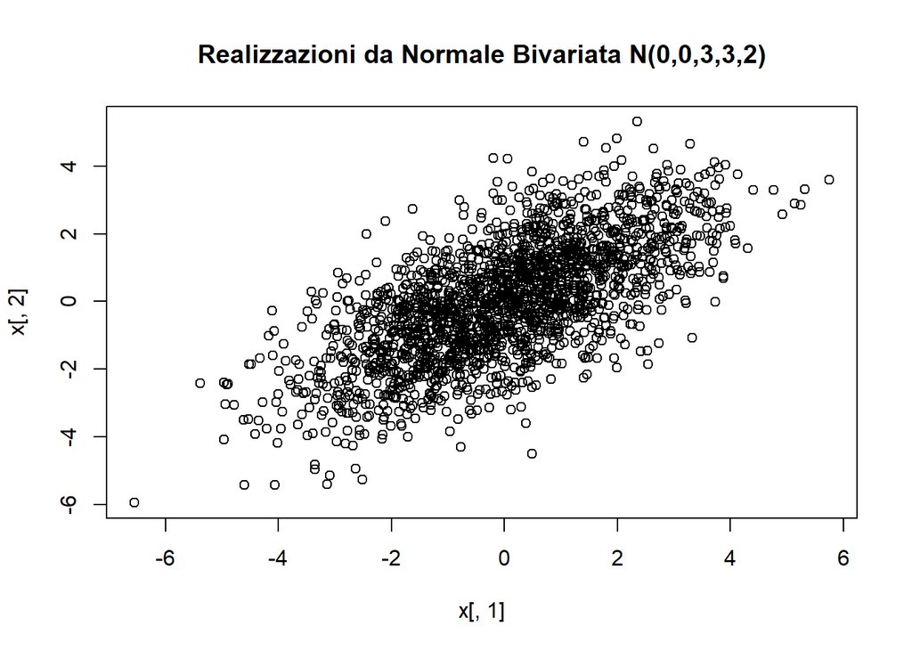

```r
plot(x[,1],
x[,2], main = "Realizzazioni da Normale Bivariata N(0,0,3,3,2)")
```

Note that the points are arranged in the shape of an ellipse with the focus centered on the averages. ### Level curves The contour line corresponds to the geometric locus of the points on the identified plane from the equation $𝑓(𝑥_1, 𝑥_2) = 𝑘$ where $𝑘$ is the level. The number of levels is set by default by contour function based on density. These are the orthogonal projections of the curves obtained by intersecting the previous graph with a plan. As $𝑘$ or the height of the plane increases, the circles get closer to the center.

Values are generated and density determined

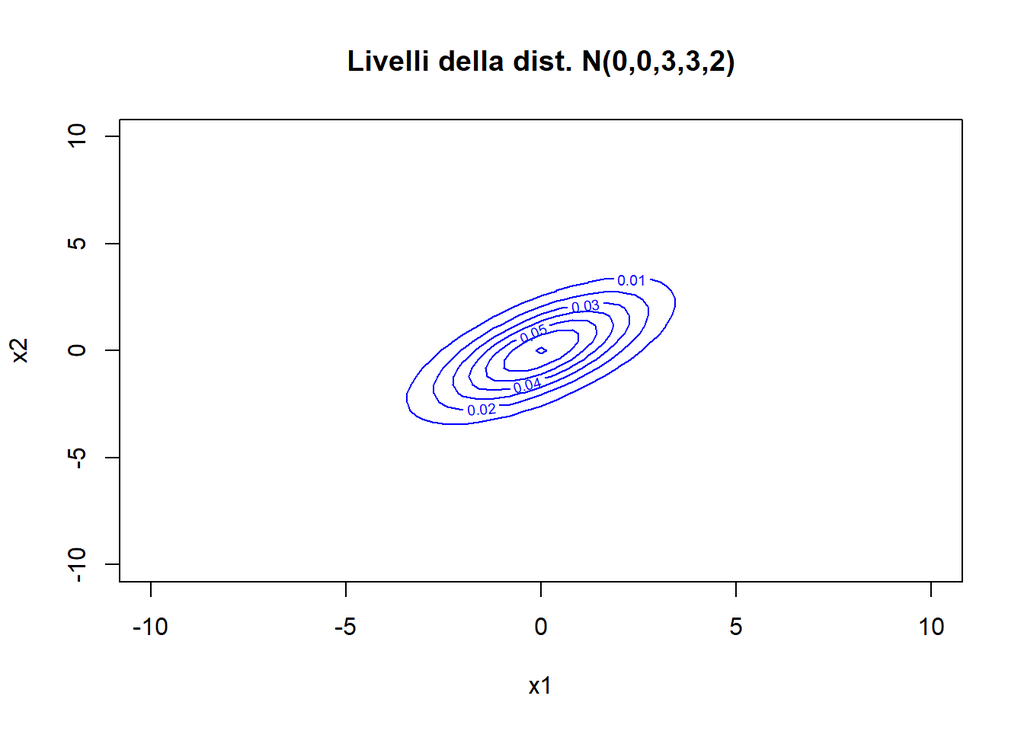

```r
x1 <- x2 <- seq(-10, 10, length = 51)
dens <- matrix(dmvnorm(expand.grid(x1, x2),
sigma = sigma1),
ncol = length(x1))
contour(x1,
x2,
dens,
main = "Livelli della dist. N(0,0,3,3,2)",
col="blue",
xlab = "x1",
ylab = "x2")
```

Note that geometrically the orientation of the ellipses allows you to establish whether the association between the two random variables is positive or negative. The center and length are also of interest of the half aces.

## Expectation-Maximization (EM) algorithm

Consider the following double-entry contingency table

| $X\|Z$ | 1 | 2 | 3 |  |
| --- | --- | --- | --- | --- |
| 1 | $y_{11}$ | $y_{12}$ | $y_{13}$ | $y_{1}$ |
| 2 | $y_{21}$ | $y_{22}$ | $NA$ | $y_{2}$ |
|  | $y_{.1}$ | $y_{.2}$ | $y_{.3}$ | $ y_{..}$ |

$$y_{ij} = \mu + \alpha_i + \beta_j +
\epsilon_{1j}$$

where $\mu$ is an intercept, $\alpha$ is the parameter for the row and $\beta$ for the column, while the hypothesis for the error term is that this component follows a Normal distribution $\epsilon_{ij} \sim N(0; \sigma^2)$.

Zero-sum constraints are placed on the parameters $\sum_i a_i = 0$ and $\sum_j \beta_j = 0$

In the following, the EM algorithm is used to estimate the model parameters and the missing data through the values of the parameters obtained upon convergence of the algorithm. The steps of the estimation procedure are as follows:

- An initial value is assigned to missing data or unobserved frequencies $y_{23}^{(0)}$.A generally used way to initialize the algorithm is to use the statistics values of the observed data. For example, you assign to $y_{23}^{(0)}$ the average value of observed frequencies. • at step E (Expectation): they calculate the parameter estimates using the known solutions in closed form with the initial values being the following

$\hat{\mu} = \bar{y}$

$\hat{\alpha}^{(0)} = \bar{y_{i.}} - \bar{y}$

$\hat{\beta_j}^{(0)} = \bar{y_{.j}} - \bar{y_{.}}$

The missing value is imputed as follows: $y_{23}^{(1)} = \hat{\mu}^{(0)} + \hat{\alpha_i}^{(0) +\hat{\beta_j}^{(0)} }$

- at step M (Maximization): we proceed iteratively by recalculating the values of parameters based on the imputed value $y_{23}^{(1)}$ until the value set for is reached the convergence criterion.

In the following example, consider the frequencies that concern two variables: 𝑋 assumption of placebo or drug and 𝑌 state of health (very bad, good, excellent). It is intended to apply the previous model and impute the missing value relating to the frequency of those who have taken the drug and have excellent health. The table with the frequencies is constructed using the matrix function and adding the missing value

```r
y <- matrix(c(10,15, 17, 22, 23, NA),2,3,byrow=TRUE); y
```

```
##      [,1] [,2] [,3]
## [1,]   10   15   17
## [2,]   22   23   NA
```

The following function called em1 assigns an initial value to the missing cell of the table and reconstructs the value based on the closed-form solutions for the model parameters (these are shown on page 69 of the handouts). Note the use of the apply function

```r
em1 <- function(y23, y){
ystar <- y
ystar[2,3] <- y23
mu.hat <- mean(ystar)
alpha.hat <- apply(ystar, MAR = 1,
mean) - mean(ystar)
beta.hat <- apply(ystar, MAR = 2,
mean) - mean(ystar)
y23 <- mu.hat + alpha.hat[2] + beta.hat[3]
return(c(mu = mu.hat,
alpha = alpha.hat,
beta = beta.hat,
y23 = y23))
}
```

The function returns the values of the model parameters obtained with the fit solutions closed

```r
em1(21,y)
```

```
##     mu alpha1 alpha2  beta1  beta2  beta3    y23
##     18     -4      4     -2      1      1     23
```

The following function em.step calls the previous function em1 to repeat the procedure calculation updating the estimates until convergence. The estimates of the maximum likelihood parameters and the corresponding are obtained as output value of the missing data. The function requires 2 inputs: • the values of the contingency table • the tolerance level 𝜖 to choose for the convergence of the EM algorithm. Among the values possible is considered $\epsilon = 10^{-8}$ or 0.00000001 indicated below with the notation 1e-8

In the body of the function, the dist function is called to calculate the distance between the values contained in the trace object at iteration h+1 and at the h-th iteration (as shown in theory lecture notes). Note the use of the while construct to increment the counter until convergence.

```r
set.seed(1832)
em.step <- function(y, epsilon= 1e-8){
trace <- NULL
convergenza <- FALSE
trace <- t(em1(y23 = mean(y, na.rm = TRUE), y = y))
y23id <- grep("y23", colnames(trace))
h <- 0
while(!convergenza){
h <- h + 1
trace <- rbind(trace,
em1(y23 = trace[h, "y23"],
y = y))
convergenza <- (dist(trace[h:(h+1), -y23id]) < epsilon)
}
return(trace)
}
```

The data matrix function applies

```r
em.step(y)
```

```
##             mu    alpha1   alpha2     beta1        beta2      beta3      y23
##  [1,] 17.40000 -3.400000 3.400000 -1.400000 1.600000e+00 -0.2000000 20.60000
##  [2,] 17.93333 -3.933333 3.933333 -1.933333 1.066667e+00  0.8666667 22.73333
##  [3,] 18.28889 -4.288889 4.288889 -2.288889 7.111111e-01  1.5777778 24.15556
##  [4,] 18.52593 -4.525926 4.525926 -2.525926 4.740741e-01  2.0518519 25.10370
##  [5,] 18.68395 -4.683951 4.683951 -2.683951 3.160494e-01  2.3679012 25.73580
##  [6,] 18.78930 -4.789300 4.789300 -2.789300 2.106996e-01  2.5786008 26.15720
##  [7,] 18.85953 -4.859534 4.859534 -2.859534 1.404664e-01  2.7190672 26.43813
##  [8,] 18.90636 -4.906356 4.906356 -2.906356 9.364426e-02  2.8127115 26.62542
##  [9,] 18.93757 -4.937570 4.937570 -2.937570 6.242951e-02  2.8751410 26.75028
## [10,] 18.95838 -4.958380 4.958380 -2.958380 4.161967e-02  2.9167607 26.83352
## [11,] 18.97225 -4.972254 4.972254 -2.972254 2.774645e-02  2.9445071 26.88901
## [12,] 18.98150 -4.981502 4.981502 -2.981502 1.849763e-02  2.9630047 26.92601
## [13,] 18.98767 -4.987668 4.987668 -2.987668 1.233175e-02  2.9753365 26.95067
## [14,] 18.99178 -4.991779 4.991779 -2.991779 8.221170e-03  2.9835577 26.96712
```

[output cut: 35 more lines]

The object that has the value of each parameter as its row is obtained at each iteration of the algorithm. Convergence with respect to the established criterion $\epsilon < 1e^{-8}$ is reached after 49 iterations. The model parameter estimates are as follows:

$\hat{\mu}= 19, \hat{\alpha_1}=-5, \hat{\alpha_2}= 5, \hat{\beta_1}= -3, \hat{\beta_2}= 0, \hat{y_{23}}=27$

## Trace plot

The graphical representation of the values obtained at each step of the algorithm, also called trace plot, is done using the matplot function

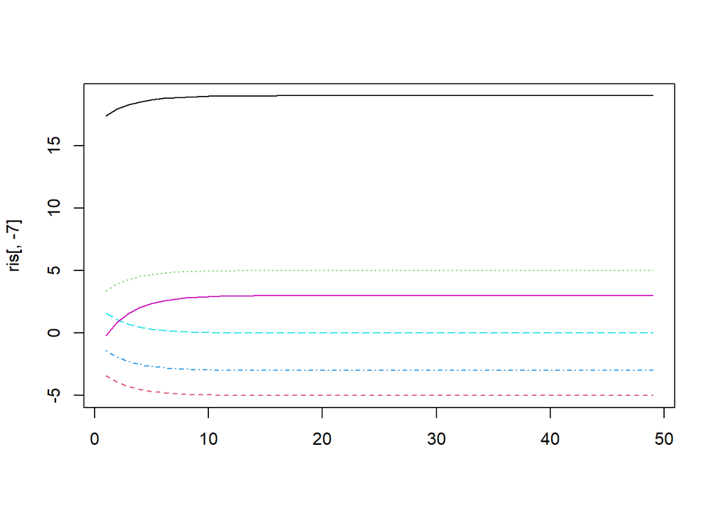

```r
ris<- em.step(y)
matplot(ris[,-7], type = "l")
```

With the following syntax you define the labels and colors and add them to the graph together to the legend.

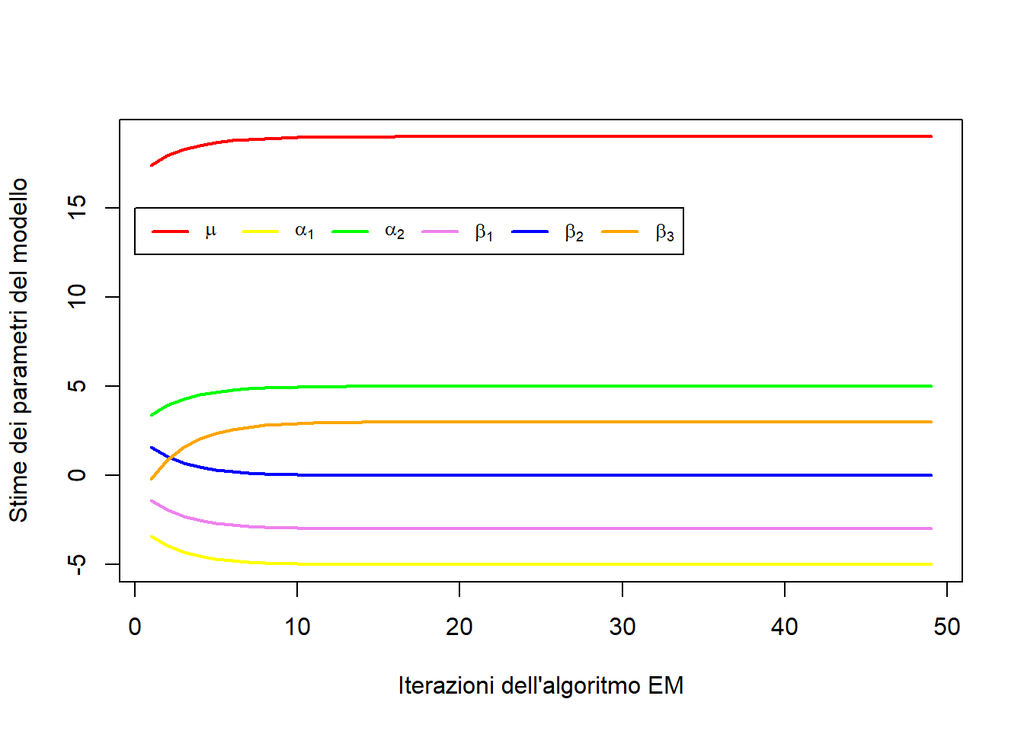

```r
names1 <- expression(mu,
alpha[1],
alpha[2],
beta[1],
beta[2],
beta[3])
pal1<- c("red", "yellow", "green", "violet", "blue", "orange")
matplot(ris[,-7],
type = "l",
col = pal1,
lwd = 2,
lty = 1,
xlab = "Iterazioni dell'algoritmo EM",
ylab = "Stime dei parametri del modello")
legend(x = 0,
y = 15,
legend = names1,
lwd = 2 ,
col = pal1,
lty = 1,
horiz=TRUE,
cex=0.8)
```

The graph allows you to view all the values of each parameter estimated at each step. The values vary particularly in the first 10 iterations and in the subsequent ones there is an adjustment which concerns the last decimal places.

# Mixture density of Gaussian components

The density is graphed for some mixture model with two components Gaussians for a specific value of the weight of each component. The function funcmxn calculates the value of the mixture density considering. The weight of the first component $\pi \in (0,1)$ indicate witn $p$.

The parameter values $\mu_1, \mu_2, \sigma_2, \sigma_2$ of the first and second components in the mu vectors and sd. Note that the function returns the value of the mixture density at a point denoted by f.

```r
funcmxn <- function(x, p, mu, sd){
f1 <- dnorm(x, mu[1], sd[1])
f2 <- dnorm(x, mu[2], sd[2])
f <- p*f1 + (1-p)*f2
f
}
```

In the following, the mixture density is represented for three distinct scenarios. ## Scenario 1 In the first scenario, a mixture with two components is considered $X_1$ and $X_2$ such taht $X_1 \sim N(11)$ and $X_2 \sim N(4,1)$ that is, with the same variability but with the weight of the first component equal to $\pi_1 = 0.4$ and for the second $1- \pi_1 = 0.6$

Si determina il valore della densità nel punto 𝑦 = 0.5.

```r
mu1 <- c(1,4)
sd1 <- c(1,1)
p1 <- 0.4
funcmxn(0.5,
p1,
mu1,
sd1)
```

```
## [1] 0.1413497
```

A density value of 0.14 is obtained. For a sequence of y values the corresponding value of the mixture density is obtained

```r
y1 <- seq(-5,10,0.01)
length(y1)
```

```
## [1] 1501
```

[output not shown]

```r
pr1 <- funcmxn(x = y1,
p = p1,
mu = mu1,
sd = sd1)
require(skimr)
skim_without_charts(pr1)
```

Data summary

| Name | pr1 |
| --- | --- |
| Number of rows | 1501 |
| Number of columns | 1 |
| _______________________ |  |
| Column type frequency: |  |
| numeric | 1 |
| ________________________ |  |
| Group variables | None |

**Variable type: numeric**

| skim_variable | n_missing | complete_rate | mean | sd | p0 | p25 | p50 | p75 | p100 |
| --- | --- | --- | --- | --- | --- | --- | --- | --- | --- |
| data | 0 | 1 | 0.07 | 0.08 | 0 | 0 | 0.02 | 0.14 | 0.24 |

It is noted that the density is concentrated between the values delimited by the interquartile difference. The obtained values are plotted to visualize the shape of the mixture density

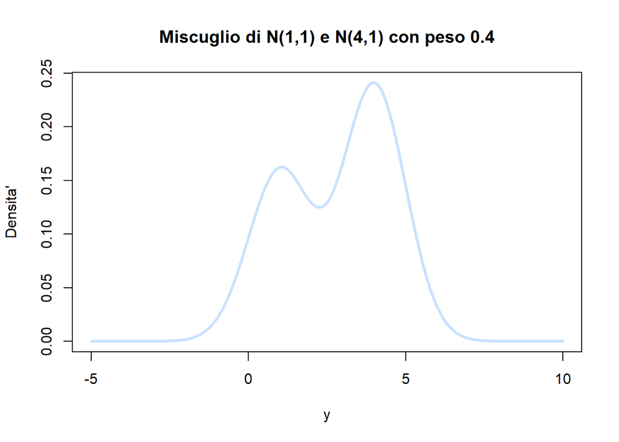

```r
plot(y1,
pr1,
xlab = "y",
ylab="Densita'",
lwd=3,
col="lightsteelblue1",
type = "l",
main="Miscuglio di N(1,1) e N(4,1) con peso 0.4")
```

Multimodality is noticeable.

Scenario 2 In the second scenario the following two components are considered $X_1$ and $X_2$ such taht $X_1 \sim N(4,1)$ and $X_2 \sim N(4,64)$ which have the same mean but the variability of the second component is very high wider than that of the first, the weight of the first component is $\pi_1 = 0.1$ and the second $1-\pi_1 = 0.9$

For $y=0.5$

```r
mu2 <- c(4,4)
sd2 <- c(1,8)
p2 <-0.1
set.seed(1235)
funcmxn(0.5,
p2,
mu2,
sd2)
```

```
## [1] 0.04087215
```

the density value is lower than that calculated in the previous scenario. A sequence of values with a wider range of variation is generated

```r
y2 <- seq(-30,40,0.01)
pr2 <- funcmxn(x = y2,
p = p2,
mu = mu2,
sd = sd2)
skim_without_charts(pr2)
```

Data summary

| Name | pr2 |
| --- | --- |
| Number of rows | 7001 |
| Number of columns | 1 |
| _______________________ |  |
| Column type frequency: |  |
| numeric | 1 |
| ________________________ |  |
| Group variables | None |

**Variable type: numeric**

| skim_variable | n_missing | complete_rate | mean | sd | p0 | p25 | p50 | p75 | p100 |
| --- | --- | --- | --- | --- | --- | --- | --- | --- | --- |
| data | 0 | 1 | 0.01 | 0.02 | 0 | 0 | 0 | 0.02 | 0.08 |

The density is concentrated between 0.0002 and 0.024. The graph allows you to detect the shape of the mixture density in the second scenario

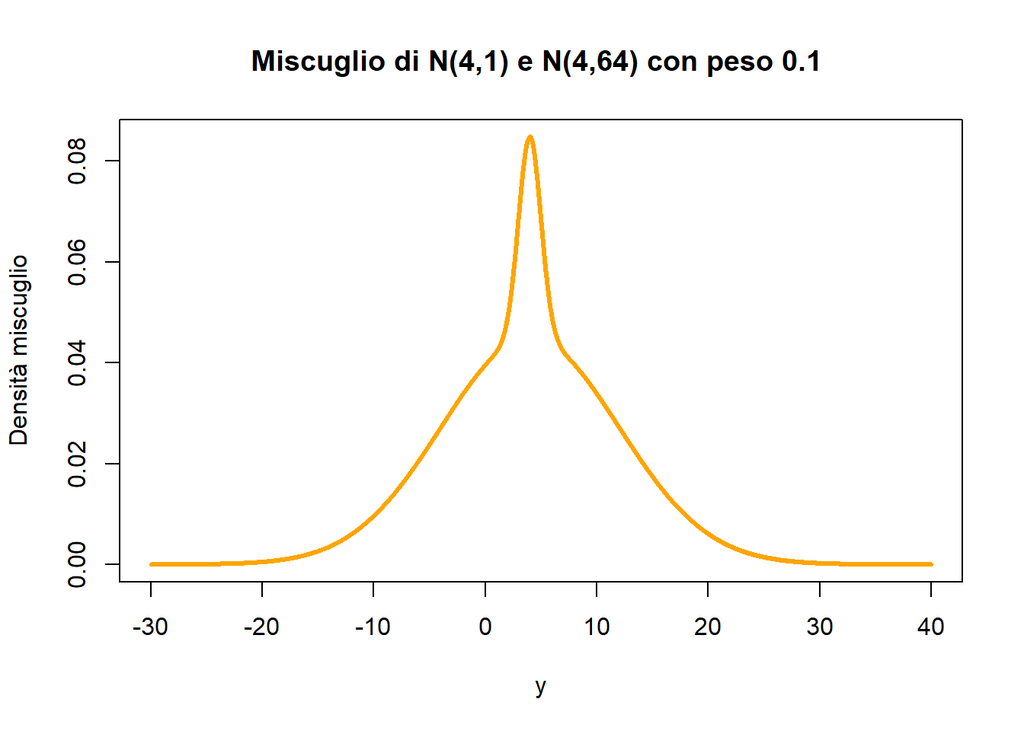

```r
plot(y2,
pr2,
xlab = "y",
ylab="Densità miscuglio",
lwd=3,
col="orange",
type = "l",
main="Miscuglio di N(4,1) e N(4,64) con peso 0.1 ")
```

## Scenario 3

In the third scenario, the value of the mixture density of two components is considered $X_1$ and $X_2$ such taht $X_1 \sim N(0,1)$ and $X_2 \sim N(0,9)$ which have the same mean but the variability of the second component is higher, the weight of the first component is equal to that of the second $\pi_1= 0.5$.

For $y=0.5$

```r
mu3 <- c(0,0)
sd3 <- c(1,3)
p3 <-0.5
funcmxn(0.5,
p3,
mu3,
sd3)
```

```
## [1] 0.2416059
```

the value is higher than the two obtained in example 1 and example 2.

For a sequence of y values (note that the sequence of values must be generated in relation to the range of variation of the two variables in order to obtain the value of the mixture density on the support considered) the corresponding density is calculated

```r
y3 <- seq(-10,20,0.01)
pr3 <- funcmxn(x = y3,
p = p3,
mu = mu3,
sd = sd3)
skim_without_charts(pr3)
```

Data summary

| Name | pr3 |
| --- | --- |
| Number of rows | 3001 |
| Number of columns | 1 |
| _______________________ |  |
| Column type frequency: |  |
| numeric | 1 |
| ________________________ |  |
| Group variables | None |

**Variable type: numeric**

| skim_variable | n_missing | complete_rate | mean | sd | p0 | p25 | p50 | p75 | p100 |
| --- | --- | --- | --- | --- | --- | --- | --- | --- | --- |
| data | 0 | 1 | 0.03 | 0.06 | 0 | 0 | 0 | 0.03 | 0.27 |

The graph allows you to detect the shape of the mixture density

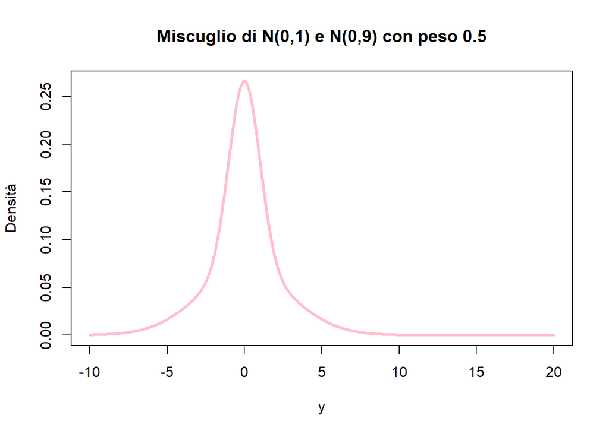

```r
plot(y3,
pr3,
xlab = "y",
ylab="Densità",
lwd=3,
col="Pink",
type = "l",
main="Miscuglio di N(0,1) e N(0,9) con peso 0.5"
)
```

## Univariate mixture model with two Gaussian components

I dati riportati in datacol.Rdata riguardano alcuni individui selezionati per uno studio al fine di valutare il ruolo del colesterolo come fattore di rischio per le malattie cardiovascolari. I valori del colesterolo (espressi in mg su dl di plasma) sono riferiti sia ai maschi (variabile binaria sex codificata con 1 per maschi) che alle femmine.

```r
load('data/datacol.Rdata')
dim(datacol)
```

```
## [1] 200   3
```

```r
head(datacol)
```

```
##     ID cholst sex
## 1 1244    175   1
## 2  835    299   0
## 3  176    250   0
## 4  901    243   0
## 5 1972    150   1
## 6 1994    234   0
```

```r
require(skimr)
skim_without_charts(datacol)
```

Data summary

| Name | datacol |
| --- | --- |
| Number of rows | 200 |
| Number of columns | 3 |
| _______________________ |  |
| Column type frequency: |  |
| numeric | 3 |
| ________________________ |  |
| Group variables | None |

**Variable type: numeric**

| skim_variable | n_missing | complete_rate | mean | sd | p0 | p25 | p50 | p75 | p100 |
| --- | --- | --- | --- | --- | --- | --- | --- | --- | --- |
| ID | 0 | 1 | 1344.43 | 774.26 | 1 | 682.5 | 1367.5 | 2012.25 | 2616 |
| cholst | 0 | 1 | 220.49 | 43.92 | 133 | 191.0 | 214.0 | 249.00 | 357 |
| sex | 0 | 1 | 0.52 | 0.50 | 0 | 0.0 | 1.0 | 1.00 | 1 |

The average level observed in the sample for cholesterol is 220.5 and presents a high variability average around the arithmetic mean is 44. The following section reports the descriptive analysis with respect to gender

```r
table(datacol$sex)
```

```
##
##   0   1
##  97 103
```

```r
require(dplyr)
```

```r
datacol%>%
dplyr::group_by(sex) %>%
skim_without_charts()
```

Data summary

| Name | Piped data |
| --- | --- |
| Number of rows | 200 |
| Number of columns | 3 |
| _______________________ |  |
| Column type frequency: |  |
| numeric | 2 |
| ________________________ |  |
| Group variables | sex |

**Variable type: numeric**

| skim_variable | sex | n_missing | complete_rate | mean | sd | p0 | p25 | p50 | p75 | p100 |
| --- | --- | --- | --- | --- | --- | --- | --- | --- | --- | --- |
| ID | 0 | 0 | 1 | 1297.75 | 769.15 | 2 | 601 | 1206 | 1994 | 2616 |
| ID | 1 | 0 | 1 | 1388.39 | 780.22 | 1 | 831 | 1442 | 2069 | 2597 |
| cholst | 0 | 0 | 1 | 222.66 | 42.67 | 134 | 192 | 216 | 243 | 340 |
| cholst | 1 | 0 | 1 | 218.45 | 45.18 | 133 | 182 | 212 | 249 | 357 |

```r
# or
# tapply(datacol$cholst, datacol$sex, summary)
# tapply(datacol$cholst, datacol$sex, sd)
```

In the sample there are 97 women and 103 men and it is noted that the average cholesterol level for for women it is 222.7 while for men it is lower at 218.4. The average variability with respect to the arithmetic mean is equal to 42 for women and 45 for i males. The following representation shows the observed values through a scatter plot: male values are represented by the larger circle

```r
n <-dim(datacol)[1]
with(datacol,
symbols(x=1:n,
y=cholst,
circles=sex,
inches=1/30 ,
xlab = "id",
ylab = "Colesterolo",
bg="red",
fg=NULL))
```

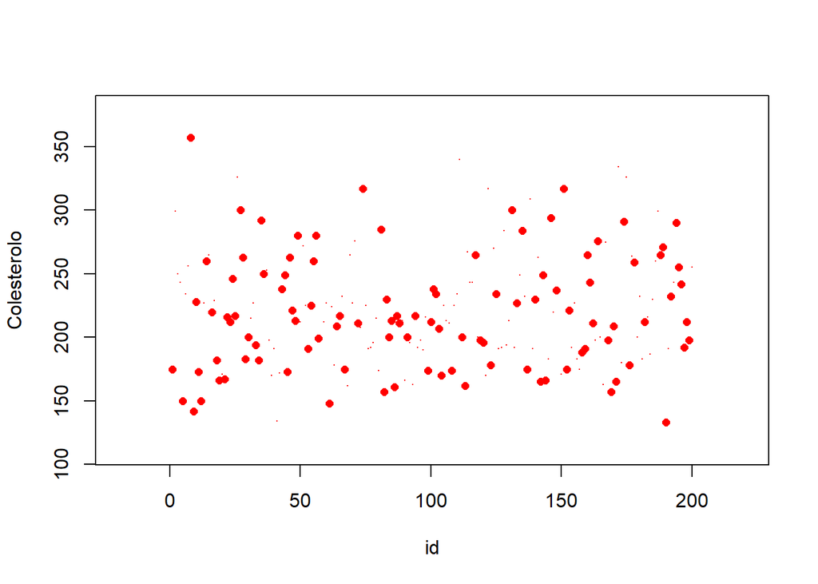

### Estimation of the parameters of the mixture model

The library called mclust (Gaussian Mixture Modeling for Model-Based Clustering) allows you to estimate the parameters of the mixture model with Gaussian components.

```r
require('mclust')
```

#### Mclust function

The main function of the mclust::Mclust library requires as arguments: - the data frame of the data, - i.e. the number of components of the mixture model (G), - the modelNames = “E” option to specify whether the model components are assumed with same variance, homoscedastic model or modelNames = “V” if assumed with specific variance for each component, heteroscedastic model

```r
mod1 <- Mclust(datacol$cholst,
G = 2,
modelNames = "E")
```

Note that the tolerance for the stopping criterion of the algorithm can be set with the option control = emControl(tol = 1.e-6)

```r
summary(mod1)
```

```
## ----------------------------------------------------
## Gaussian finite mixture model fitted by EM algorithm
## ----------------------------------------------------
##
## Mclust E (univariate, equal variance) model with 2 components:
##
##  log-likelihood   n df       BIC       ICL
##       -1032.055 200  4 -2085.302 -2126.187
##
## Clustering table:
##   1   2
## 158  42
```

The summary function returns: - the value of the log-likelihood function at convergence after the parameters were estimated with the EM algorithm. - number of model parameters free to vary (in the model with two components are given by the two means, the variance and the weight).

Parameter estimates are requested with

```r
summary(mod1,parameters = TRUE)
```

```
## ----------------------------------------------------
## Gaussian finite mixture model fitted by EM algorithm
## ----------------------------------------------------
##
## Mclust E (univariate, equal variance) model with 2 components:
##
##  log-likelihood   n df       BIC       ICL
##       -1032.055 200  4 -2085.302 -2126.187
##
## Clustering table:
##   1   2
## 158  42
##
## Mixing probabilities:
##         1         2
## 0.7777503 0.2222497
##
## Means:
##        1        2
## 203.7208 279.1730
##
## Variances:
##        1        2
## 935.6102 935.6102
```

Where: - Mixing probable are the estimates of the weights $\hat{\pi}$ of each component, $= 0.78 $ for the first and $\hat{\pi_2}= 0.22$ for the second.

- means the values of the averages of the two components. From the estimates it can be seen that the first component is represented by a Normal random variable with mean value $\hat{\mu_1}= 204$, while the second $\hat{\mu_2} = 279$
- Variances: the estimates of the variances of the components. Since by hypothesis they are the same this is the estimate of a single variance $\hat{\sigma^2} = 936$. This indicates that on average both in the first and second subpopulation the average variability with respect to the value average is 30 mg per dl of plasma.

From the estimation of this mixture model we know that the population is characterized by a mixture of two subpopulations the first described by $X_1 \sim N(204, 936)$ and the second is $X_2 \sim N(279, 936)$

Classification of units - clustering table returns the total number of patients that have been classified as belonging to the first or second component.

Note that this assignment is made with respect to the posterior probabilities that are found in object z

```r
head(mod1$z)
```

```
##            [,1]         [,2]
## [1,] 0.99863336 0.0013666414
## [2,] 0.03184899 0.9681510115
## [3,] 0.63194159 0.3680584100
## [4,] 0.75129790 0.2487021035
## [5,] 0.99981810 0.0001819027
## [6,] 0.86199548 0.1380045218
```

According to this mixture model with two components the first unit has a probability almost certain on the first component. The second unit, on the other hand, has a posterior probability greater than being classified in the second component. While the fourth unit has a probability of 0.75 of being classified in the first component and 0.25 of being classified in the second component. Based on this uncertainty of the a posteriori classification, the term of is calculated penalty present in the ICL information criterion, reported in the model summary. Note that it is possible to adopt the criterion of the maximum a posteriori probability that will come shown below also applying the which.max function

```r
head(apply(mod1$z,1,which.max))
```

```
## [1] 1 2 1 1 1 1
```

which returns the vector of elements 1 or 2 if the id is classified in the first or in the second component respectively. The following graph instead allows you to view all the observed values of black cholesterol, and which values are classified into group 2 red and group 1 blue.

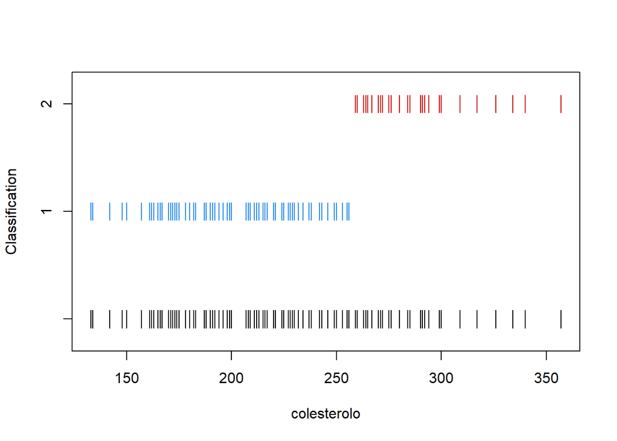

```r
plot(mod1,
what='classification', xlab = "colesterolo")
```

From the graph you can see the cholesterol value that discriminates the two subpopulations is slightly above 250. We can see how the units were classified according to male or female gender

```r
class<-mod1$classification; head(class)
```

```
## [1] 1 2 1 1 1 1
```

```r
table(class,datacol$sex)
```

```
##
## class  0  1
##     1 78 80
##     2 19 23
```

The two genders are present in almost equal numbers in the two groups. 78% of the subjects belong to the first component. #### Representation of mixture density The mixed density graph is obtained as follows

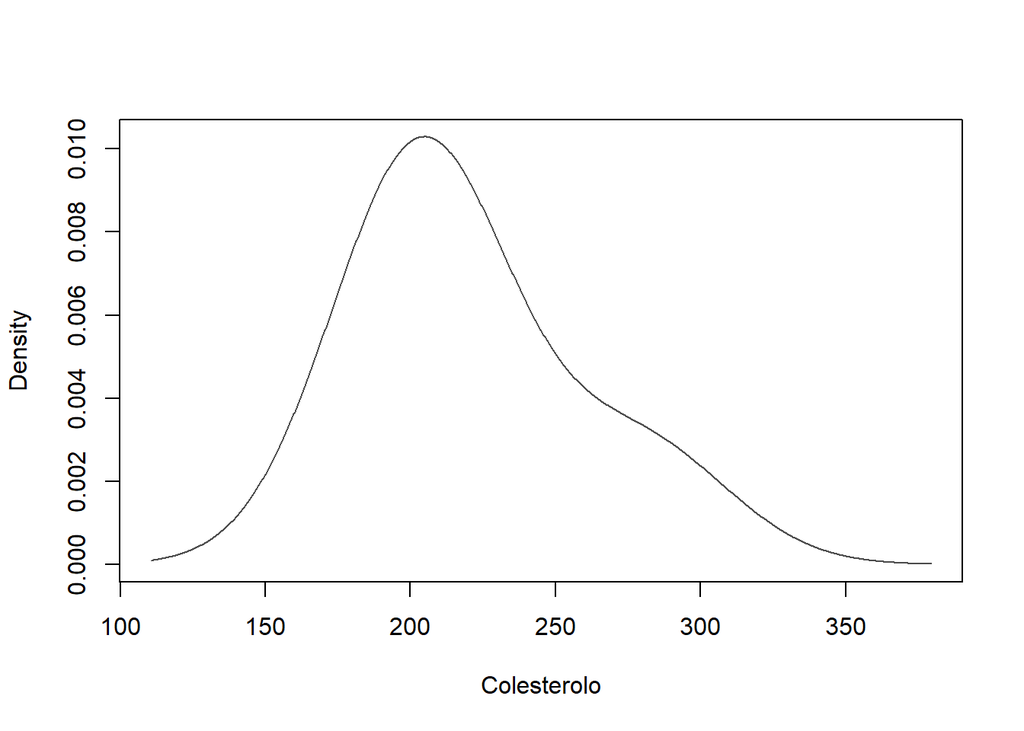

```r
plot(mod1,
what='density', xlab = "Colesterolo")
```

### Choice of the number of components

The mclus:mclustBIC function allows you to display the information criterion values Bayesian (BIC) when mixture models with numeric components are estimated growing. The BIC is calculated with respect to mixture models that differ in the number of components depending on whether these have the same variance (option E) or different variability (option V). The function takes the data vector as input

```r
bayesinf <- mclustBIC(datacol$cholst)
bayesinf
```

```
## Bayesian Information Criterion (BIC):
##           E         V
## 1 -2090.155 -2090.155
## 2 -2085.302 -2089.269
## 3 -2096.304 -2103.554
## 4 -2104.550 -2118.857
## 5 -2114.649 -2124.799
## 6 -2123.391 -2149.002
## 7 -2134.099 -2134.237
## 8 -2144.769 -2142.100
## 9 -2155.475 -2132.422
##
## Top 3 models based on the BIC criterion:
##       E,2       V,2       E,1
## -2085.302 -2089.269 -2090.155
```

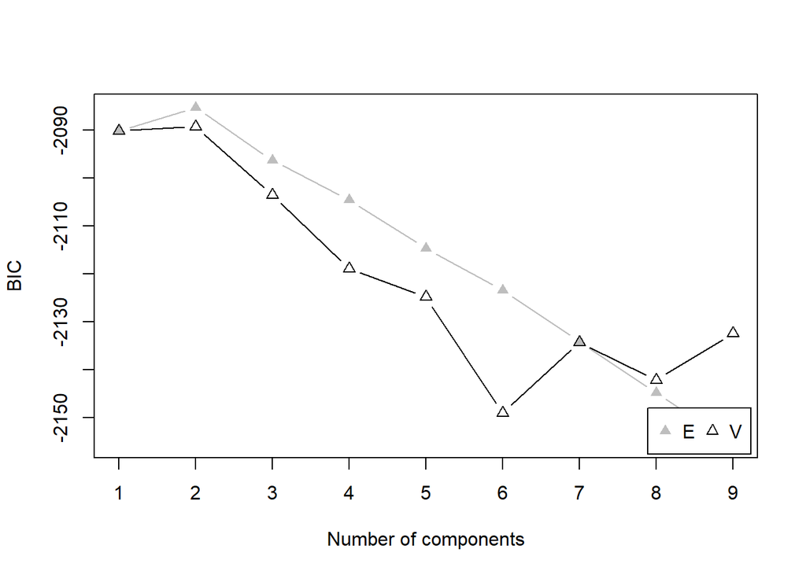

```r
plot(bayesinf)
```

### Multivariate mixture model with Gaussian components

The values representing the findings compared to two clinical tests performed are considered on 200 patients (simulated data). In the data.Rdata file, assume that $Y_1$ represents the level of white blood cells and $Y_2$ the hemoglobin level.

```r
load("data/data.Rdata")
head(data)
```

```
##       Y1.1     Y2.1
## 1 185.2594 222.6894
## 2 209.0801 248.5053
## 4 229.8731 205.3069
## 5 289.8899 218.1793
## 7 254.6754 222.6894
## 8 204.2028 188.8758
```

For the first patient the reading of white blood cells is 185 while that of hemoglobin of 223.

```r
require(skimr)
skim_without_charts(data)
```

Data summary

| Name | data |
| --- | --- |
| Number of rows | 200 |
| Number of columns | 2 |
| _______________________ |  |
| Column type frequency: |  |
| numeric | 2 |
| ________________________ |  |
| Group variables | None |

**Variable type: numeric**

| skim_variable | n_missing | complete_rate | mean | sd | p0 | p25 | p50 | p75 | p100 |
| --- | --- | --- | --- | --- | --- | --- | --- | --- | --- |
| Y1.1 | 0 | 1 | 206.39 | 36.96 | 100.18 | 185.26 | 204.2 | 229.87 | 319.39 |
| Y2.1 | 0 | 1 | 212.30 | 36.11 | 126.13 | 184.78 | 213.8 | 237.32 | 302.96 |

Patients have an average white blood cell level of 206 and hemoglobin level of 212. Variability average around the average is around 37 for white blood cells and 36 for hemoglobin.

```r
cov(data)
```

```
##           Y1.1      Y2.1
## Y1.1 1366.1894  812.4941
## Y2.1  812.4941 1304.0416
```

```r
cor(data)
```

```
##          Y1.1     Y2.1
## Y1.1 1.000000 0.608722
## Y2.1 0.608722 1.000000
```

The sample linear correlation coefficient is 0.6 and suggests a positive association quite high between the two variables. The two graphs highlight this association

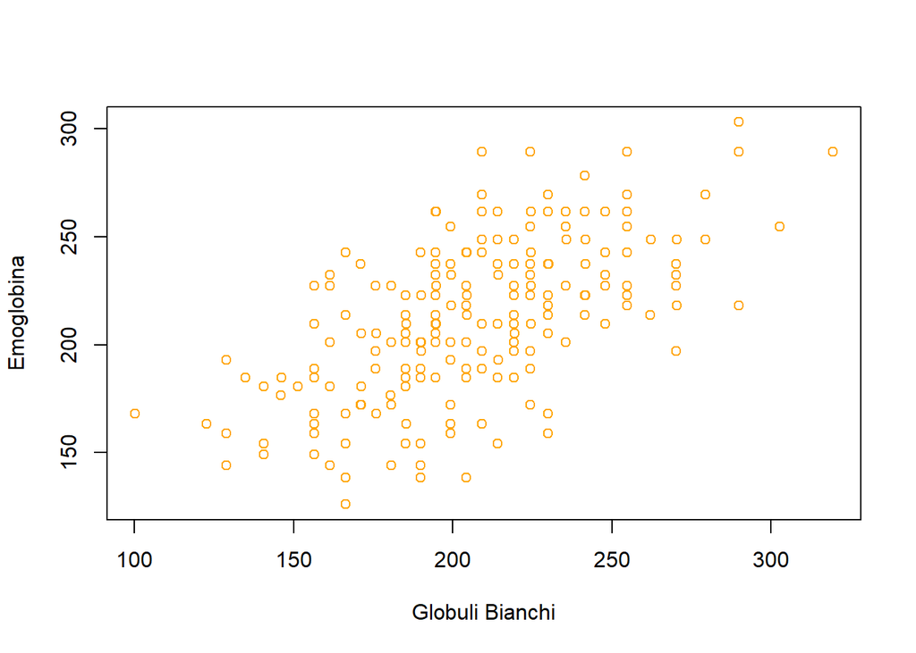

```r
plot(data$Y1.1, data$Y2.1, xlab = "Globuli Bianchi",
ylab = "Emoglobina", col = "orange")
```

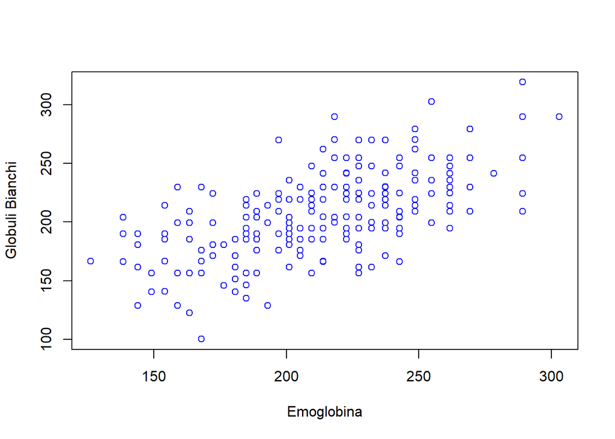

```r
plot(data$Y2.1, data$Y1.1,
xlab = "Emoglobina", ylab = "Globuli Bianchi", col = "blue")
```

The multivariate mixture model is estimated with the mclust library using decomposition spectral for the variance-covariance matrix of the components. Initially the spherical model is considered. The following specifications EII and VII define the spherical model or the model in which the components are independent with the same variance E or different variance V.

## Selection of the number of components

As in the univariate case, the selection of the components occurs with the information criterion Bayesian in the following way

```r
require(mclust)
mcc <-Mclust(data, modelNames = c("EII", "VII"))
mcc$BIC
```

```
## Bayesian Information Criterion (BIC):
##         EII       VII
## 1 -4027.750 -4027.750
## 2 -3972.182 -3977.513
## 3 -3970.082 -3978.606
## 4 -3974.086 -3988.241
## 5 -3989.188 -4007.767
## 6 -4002.328 -4025.495
## 7 -4014.416 -4043.538
## 8 -4030.288 -4058.401
## 9 -4045.601 -4078.349
##
## Top 3 models based on the BIC criterion:
##     EII,3     EII,2     EII,4
## -3970.082 -3972.182 -3974.086
```

Evaluating a few different models for an increasing number of components with equal variance or different the criterion suggests 3 components with equal variance (E). ## Parameter estimation The model selected as best is estimated as follows

```r
mc <-Mclust(data,
G = 3,
modelNames = c("EII"))
summary(mc,parameters = TRUE )
```

```
## ----------------------------------------------------
## Gaussian finite mixture model fitted by EM algorithm
## ----------------------------------------------------
##
## Mclust EII (spherical, equal volume) model with 3 components:
##
##  log-likelihood   n df       BIC       ICL
##       -1961.199 200  9 -3970.082 -4053.728
##
## Clustering table:
##   1   2   3
## 105  55  40
##
## Mixing probabilities:
##         1         2         3
## 0.4897486 0.2813647 0.2288867
##
## Means:
##          [,1]     [,2]     [,3]
## Y1.1 202.5506 244.8475 167.3407
## Y2.1 212.4403 246.9436 169.4106
##
## Variances:
## [,,1]
##          Y1.1     Y2.1
## Y1.1 562.8875   0.0000
## Y2.1   0.0000 562.8875
## [,,2]
##          Y1.1     Y2.1
## Y1.1 562.8875   0.0000
## Y2.1   0.0000 562.8875
## [,,3]
##          Y1.1     Y2.1
## Y1.1 562.8875   0.0000
## Y2.1   0.0000 562.8875
```

The parameters free to vary in the model are 9 because the model is multivariate. The parameters are the following: - The weights of two components (mixing probabilities, the third is determined by difference with respect to the sum constraint 1) - The values of the means for the two variables in each subpopulation (6 means) - The variance assumed to be equal for all components (1 variance) From the estimated values we note that: - The weight of each group is as follows 49% for the first group, 28% for the second, and 23% for the third. - The third subpopulation (group 3) is made up of those who have the highest average values low for both variables. - The first subpopulation represents those who have average white blood cell values and hemoglobin 202 and 212 respectively. - The second subpopulation is characterized by those who have the highest average values and equal to 245 and 247. - The average variability around the mean is the same for all components and is 23.

The classification chart below shows how drives are allocated into the three groups.

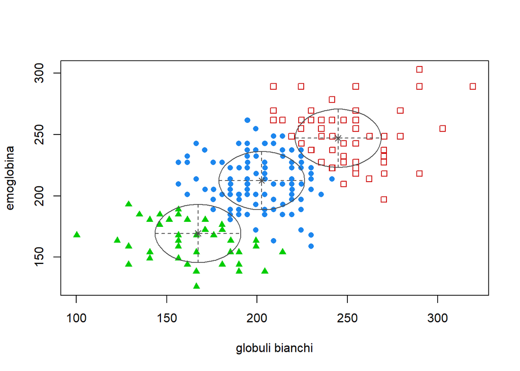

```r
plot(mc,"classification", xlab = "globuli bianchi",
ylab = "emoglobina")
```

The ellipses represent the univariate density of each component: they have the same shape with focus corresponding to the estimated group means and have no orientation. The mixture density contour lines are obtained as follows.

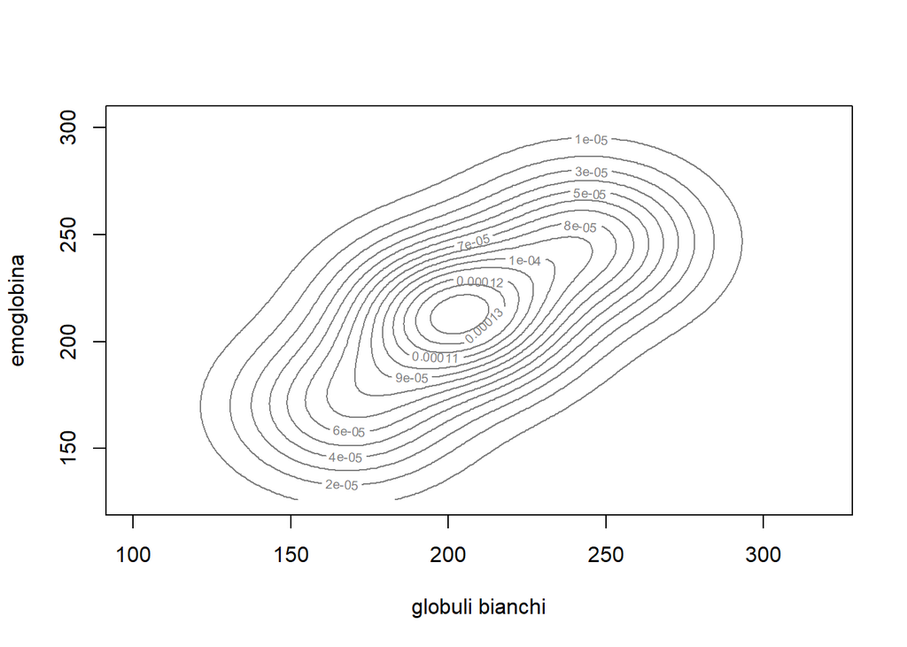

```r
plot(mc,"density", xlab = "globuli bianchi", ylab = "emoglobina")
```

The greatest density is concentrated at the point of intersection of the sample means. The ellipses are oriented to the right since there is a positive correlation between the two variables. ### Mixture model with spherical components and specific variances for each component The model with non-homogeneous distribution between groups postulates different variances for each component and is specified with option VII

```r
mc1 <-Mclust(data, G = 3, modelNames = c( "VII"))
summary(mc1, parameters = TRUE)
```

```
## ----------------------------------------------------
## Gaussian finite mixture model fitted by EM algorithm
## ----------------------------------------------------
##
## Mclust VII (spherical, varying volume) model with 3 components:
##
##  log-likelihood   n df       BIC       ICL
##       -1960.162 200 11 -3978.606 -4064.025
##
## Clustering table:
##  1  2  3
## 88 66 46
##
## Mixing probabilities:
##         1         2         3
## 0.4174926 0.3375221 0.2449853
##
## Means:
##          [,1]     [,2]     [,3]
## Y1.1 200.7391 240.7749 168.6567
## Y2.1 211.3657 244.2084 169.9287
##
## Variances:
## [,,1]
##          Y1.1     Y2.1
## Y1.1 455.8909   0.0000
## Y2.1   0.0000 455.8909
## [,,2]
##          Y1.1     Y2.1
## Y1.1 676.6679   0.0000
## Y2.1   0.0000 676.6679
## [,,3]
##          Y1.1     Y2.1
## Y1.1 560.0236   0.0000
## Y2.1   0.0000 560.0236
```

Note that the following graph shows ellipses of different widths representing the three components having different variability.

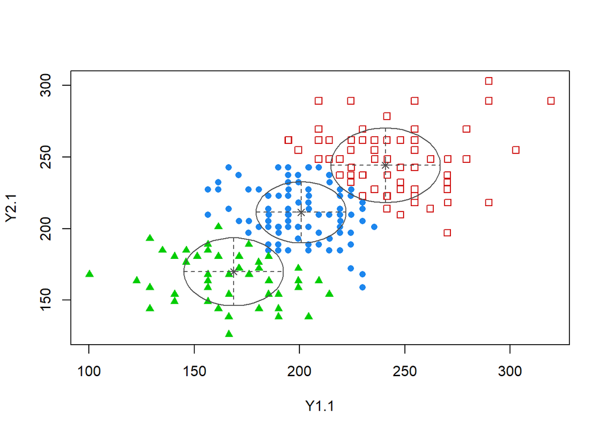

```r
plot(mc1,"classification")
```

## Non-spherical mixture model

In the event that a covariance between the response variables other than zero is also assumed specific for each component, the mixture model is estimated with the VEE option which assumes the same shape for the densities and same orientation

```r
mc2 <-Mclust(data, G = 3, modelNames = c( "VEE"))
summary(mc2, parameters = TRUE)
```

```
## ----------------------------------------------------
## Gaussian finite mixture model fitted by EM algorithm
## ----------------------------------------------------
##
## Mclust VEE (ellipsoidal, equal shape and orientation) model with 3 components:
##
##  log-likelihood   n df       BIC       ICL
##       -1956.648 200 13 -3982.174 -4089.575
##
## Clustering table:
##  1  2  3
## 77 69 54
##
## Mixing probabilities:
##         1         2         3
## 0.3615714 0.3586530 0.2797756
##
## Means:
##          [,1]     [,2]     [,3]
## Y1.1 202.4390 234.6283 175.3050
## Y2.1 213.1036 244.0587 170.5467
##
## Variances:
## [,,1]
##           Y1.1      Y2.1
## Y1.1 617.83969  94.39148
## Y2.1  94.39148 347.15298
## [,,2]
##          Y1.1     Y2.1
## Y1.1 987.4120 150.8535
## Y2.1 150.8535 554.8090
## [,,3]
##          Y1.1     Y2.1
## Y1.1 782.0067 119.4724
## Y2.1 119.4724 439.3955
```

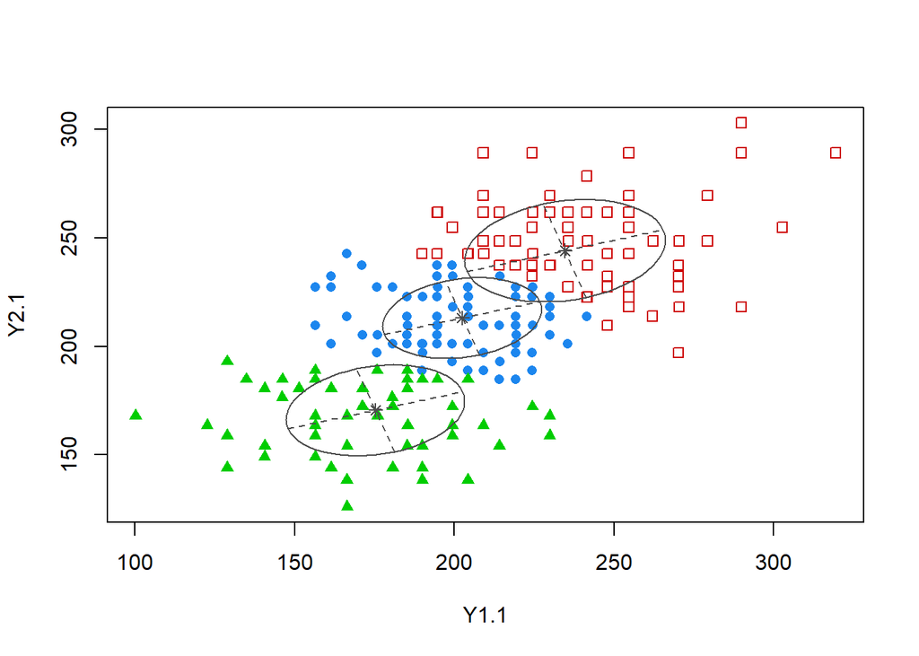

```r
plot(mc2,"classification")
```

## Bootstrap for standard errors and confidence intervals

The confidence intervals for the model parameters are obtained by applying bootstrap the percentile method. Below we illustrate the application of the bootstrap for the first model that takes on structure spherical and absence of correlation (EII). The mclust::bootClust function allows you to get the boostrap sampling results using by default 𝐵 = 999 bootstrap samples

```r
bootClust <- MclustBootstrap(mc)
```

The summary function returns the results by reporting the estimated standard errors for each parameter

```r
summary(bootClust, what = "se")
```

```
## ----------------------------------------------------------
## Resampling standard errors
## ----------------------------------------------------------
## Model                      = EII
## Num. of mixture components = 3
## Replications               = 999
## Type                       = nonparametric bootstrap
##
## Mixing probabilities:
##          1          2          3
## 0.06830526 0.09941863 0.07588911
##
## Means:
##             1        2        3
## Y1.1 7.563568 16.60598 7.475757
## Y2.1 8.214820 11.32911 5.311737
##
## Variances:
## [,,1]
##         Y1.1    Y2.1
## Y1.1 48.2646  0.0000
## Y2.1  0.0000 48.2646
## [,,2]
##         Y1.1    Y2.1
## Y1.1 48.2646  0.0000
## Y2.1  0.0000 48.2646
## [,,3]
##         Y1.1    Y2.1
## Y1.1 48.2646  0.0000
## Y2.1  0.0000 48.2646
```

and the confidence intervals calculated at the 95% confidence level.

```r
summary(bootClust, what = "ci")
```

```
## ----------------------------------------------------------
## Resampling confidence intervals
## ----------------------------------------------------------
## Model                      = EII
## Num. of mixture components = 3
## Replications               = 999
## Type                       = nonparametric bootstrap
## Confidence level           = 0.95
##
## Mixing probabilities:
##               1          2         3
## 2.5%  0.3655952 0.03388683 0.1262837
## 97.5% 0.6446172 0.39446999 0.4370823
##
## Means:
## [,,1]
##           Y1.1     Y2.1
## 2.5%  195.5367 201.2128
## 97.5% 224.9258 233.4173
## [,,2]
##           Y1.1     Y2.1
## 2.5%  234.1689 239.6560
## 97.5% 297.3753 285.3773
## [,,3]
##           Y1.1     Y2.1
## 2.5%  152.7594 162.7716
## 97.5% 181.2393 184.0687
##
## Variances:
## [,,1]
##           Y1.1     Y2.1
## 2.5%  453.0529 453.0529
## 97.5% 639.8634 639.8634
## [,,2]
##           Y1.1     Y2.1
## 2.5%  453.0529 453.0529
## 97.5% 639.8634 639.8634
## [,,3]
##           Y1.1     Y2.1
## 2.5%  453.0529 453.0529
## 97.5% 639.8634 639.8634
```

## Latent class model

Consider the following data regarding the responses to two tests administered to patients of an oncology department to evaluate depression and anxiety. (The data is taken from Zigmond, A. and Snaith, R. (1983), The hospital anxiety and depression scale, Acta Psychiatrika Scandinavica, 67, 361-370.)

```r
load("data/psico.Rdata")
dim(Y)
```

```
## [1] 201   2
```

```r
head(Y)
```

```
##      [,1] [,2]
## [1,]    1    1
## [2,]    0    0
## [3,]    0    0
## [4,]    1    1
## [5,]    0    0
## [6,]    0    0
```

```r
tail(Y)
```

```
##        [,1] [,2]
## [196,]    1    0
## [197,]    2    1
## [198,]    1    1
## [199,]    0    0
## [200,]    3    3
## [201,]    0    0
```

The observations in the first column refer to the first item of the questionnaire it measures depression and those in the second column refer to the second item which measures anxiety. The items are measured on an ordinal scale with four levels coded from 0 to 3: 0 low, 1 medium-low, 2 medium, 3 high. 201 patients responded to the questionnaire and the relative frequency of each category can be displayed with the apply function as follows

```r
n<-dim(Y)[1]
apply(Y,2,table)/n
```

```
##         [,1]       [,2]
## 0 0.35323383 0.39800995
## 1 0.52736318 0.46268657
## 2 0.07960199 0.09950249
## 3 0.03980100 0.03980100
```

Dalle frequenze relative per ogni categoria di risposta si nota che il 52% dei pazienti ha una depressione medio-bassa ed il 46% un livello di ansia medio-basso. Solo il 4% presenta alti livelli di depressione e di ansia.

Il modello a classi latenti con distribuzione non parametrica per la variabile latente con supporto discreto e supposta con un numero di punti di supporto finito viene stimato con la libreria MultiLCIRT (Multidimensional Latent Class Item Response Theory) e la funzione est_multi_poly.

La funzione richiede che si determini il pattern delle configurazioni di risposta utilizzando la funzione aggr_data nel modo seguente

```r
require(MultiLCIRT)
Yout <- aggr_data(Y)
S <- Yout$data_dis;S
```

```
##       [,1] [,2]
##  [1,]    1    1
##  [2,]    0    0
##  [3,]    1    0
##  [4,]    2    2
##  [5,]    2    1
##  [6,]    0    1
##  [7,]    1    2
##  [8,]    0    2
##  [9,]    2    0
## [10,]    3    1
## [11,]    3    3
## [12,]    3    2
## [13,]    2    3
## [14,]    1    3
```

```r
yv <- Yout$freq; yv
```

```
##  [1] 77 59 20  6  6  7  8  5  1  3  4  1  3  1
```

```r
cbind(S,yv)
```

```
##           yv
##  [1,] 1 1 77
##  [2,] 0 0 59
##  [3,] 1 0 20
##  [4,] 2 2  6
##  [5,] 2 1  6
##  [6,] 0 1  7
##  [7,] 1 2  8
##  [8,] 0 2  5
##  [9,] 2 0  1
## [10,] 3 1  3
## [11,] 3 3  4
## [12,] 3 2  1
## [13,] 2 3  3
## [14,] 1 3  1
```

```r
mod2 <- est_multi_poly(S,yv,k=2)
```

```
## *-------------------------------------------------------------------------------*
## Link of type =                  0
## Discrimination index =          0
## Constraints on the difficulty = 0
## Type of initialization =        0
## *-------------------------------------------------------------------------------*
```

```r
summary(mod2)
```

```
##
## Call:
## est_multi_poly(S = S, yv = yv, k = 2)
##
## Log-likelihood:
## [1] -374.62
##
## AIC:
## [1] 775.23
##
## BIC:
## [1] 818.18
##
## Class weights:
## [1] 0.4782 0.5218
##
## Conditional response probabilities:
## , , class = 1
##
##         item
## category      1      2
##        0 0.7387 0.8324
##        1 0.2474 0.1024
##        2 0.0138 0.0652
##        3 0.0000 0.0000
##
## , , class = 2
##
##         item
## category      1      2
##        0 0.0000 0.0000
##        1 0.7839 0.7928
##        2 0.1399 0.1309
##        3 0.0763 0.0763
```

```r
mod2$np
```

```
## [1] 13
```

The value of the convergence log-likelihood of the EM algorithm is -374.62 and the model with two latent classes it has 13 parameters free to vary, and the value of the information criterion Bayesian is 818.18. From the parameter estimates we note that the weight of the first component is 0.48 while that of the second component is 0.52. From the estimates of the conditional probabilities we can characterize the first latent class such as that referring to the subpopulation of patients at low risk of depression and anxiety as the probability of reporting a high level of depression or anxiety is zero and is the probability of responding in the first category of both variables is high. The second latent class represents more than half of the patient population and is characterized by those who are more prone to depression and anxiety because the probability of the first category is zero while the probability for the remaining ones is higher categories. The classification of patients into the two groups occurs with a posteriori probabilities. This is required by specifying output = TRUE in the estimate function and then the probabilities are contained in the Pp object of the model.

```r
mod2 <- est_multi_poly(S,yv,k=2,
output = TRUE)
```

```
## *-------------------------------------------------------------------------------*
## Link of type =                  0
## Discrimination index =          0
## Constraints on the difficulty = 0
## Type of initialization =        0
## *-------------------------------------------------------------------------------*
```

```r
round(mod2$Pp,2)
```

```
##       [,1] [,2]
##  [1,] 0.04 0.96
##  [2,] 1.00 0.00
##  [3,] 1.00 0.00
##  [4,] 0.04 0.96
##  [5,] 0.01 0.99
##  [6,] 1.00 0.00
##  [7,] 0.13 0.87
##  [8,] 1.00 0.00
##  [9,] 1.00 0.00
## [10,] 0.00 1.00
## [11,] 0.00 1.00
## [12,] 0.00 1.00
## [13,] 0.00 1.00
## [14,] 0.00 1.00
```

We note that for those who have a response pattern of 1,1 (first row of the S matrix) the estimated a posteriori probabilities are 0.036 and 0.964 of belonging to the first and second latent class respectively. With the rule of maximum a posteriori probability these patients are allocated to the second latent class. Considering those who have response patterns 1, 2 (line 7 of S) we notice that in line 7 of Pp we have 0.126 and 0.874. So those who have a medium-low level of depression and a medium level of anxiety are allocated with probability 0.9 in the second latent class.

# Exercise:

## Realizations from the Bivariate Normal distribution

Exercise 31 1. Obtain first 10 and then 3000 realizations from a Normal distribution double $(𝑋_1, 𝑋_2) \sim 𝑁 (\mu_1, \mu_2, \sigma_1^2, \sigma_2^2, \sigma_{12}$ with the following parameter values: $𝑁 (0, 0, 3, 3, 0)$. Set the seed to the value 14263. 2. Describe the data generated considering 𝑛 = 3000 and draw the empirical distribution. Yes comments. 3. Draw the scatter plot of the realizations and comment on them. 4. Draw and interpret the level curves obtained from the theoretical distribution.

31.1. To obtain pseudo-random realizations from a Bivariate Normal Random Variable you use the rmvnorm function from the mvtnorm package. This command requires as arguments the number of values to generate (n), the vector of means (mean) and the variance covariance matrix (sigma).

```r
require(mvtnorm)
medie <- c(0, 0)
varcov <- matrix(c(3, 0, 0, 3), ncol = 2, byrow = TRUE)
set.seed(14263)
x <- mvtnorm::rmvnorm(n = 3000, mean = medie, sigma = varcov)
```

31.2. The object returned in output from the rmvnorm function is a matrix of two columns and 3000 rows: the two columns represent the two components $(𝑋_1 and X_2)$ of the bivariate variable, while each row corresponds to a different observation. We calculate the sample values of the means and the variance covariance matrix with the corresponding ones theorists.

```r
apply(x, 2, mean)
```

```
## [1] -0.03755349 -0.07563272
```

```r
cov(x)
```

```
##              [,1]         [,2]
## [1,]  2.984626483 -0.004400598
## [2,] -0.004400598  3.068788617
```

We observe, for all the indices considered, a good adherence of the empirical values obtained to those of the theoretical distribution.

We also note that, in this case, the covariance between the two components is equal to 0, i.e two components are uncorrelated. It follows that they are also independent: the first component (first column) has Univariate Normal distribution with mean 0 and variance 3, i.e. 𝑋1 ∼ 𝑁 (0, 3), while the second component (second column) in turn has Univariate Normal distribution with mean 0 and variance 3, i.e. 𝑋2 ∼ 𝑁 (0, 3), independent of the first. It is important to underline that this result does not hold in general if the two components are correlated, that is, if 𝜎12 ≠ 0. In conclusion, we represent the two empirical distribution functions in the same graphic window.

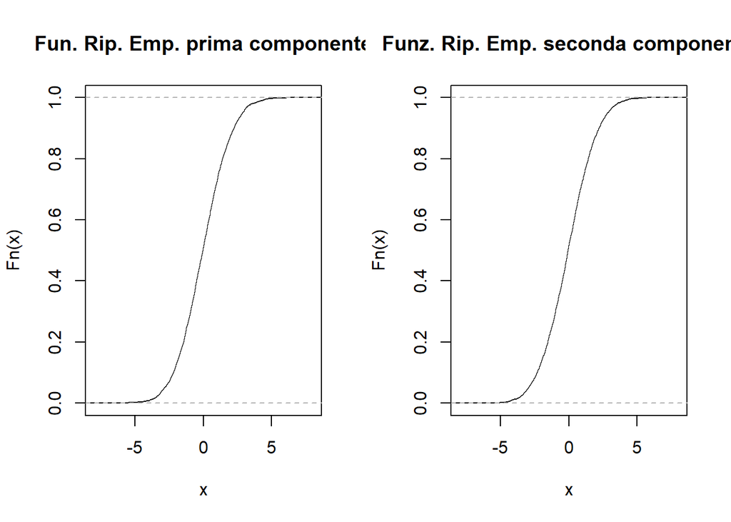

```r
par(mfrow=c(1, 2))
plot(ecdf(x[, 1]),
do.points = FALSE,
xlim = c(-8, 8),
main = 'Fun. Rip. Emp. prima componente')
plot(ecdf(x[, 2]),
do.points = FALSE,
xlim = c(-8, 8),
main = 'Funz. Rip. Emp. seconda componente')
```

Confirming the fact that the two components can be considered as generated by the same one univariate Gaussian distribution (𝑁 (0, 3)), the two curves are substantially indistinguishable from each other on the other; it can also be observed that they follow the function curve practically perfectly of theoretical distribution for a V.C. corresponding.

31.3.

We visualize the scatter graph by simply plotting the vectors relating to the two in the plane components of the bivariate distribution (x-axis: first component, y-axis: second component).

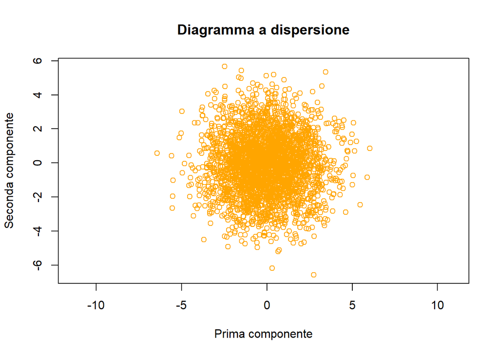

```r
plot(x[, 1], x[, 2],
col = "orange",
asp = 1,
main = "Diagramma a dispersione",
xlab = "Prima componente",
ylab = "Seconda componente")
```

The asp = 1 option allows you to use the same unit of measurement for the x axis and y axis. This allows you to precisely visualize the shape of the point cloud, highlighting in particular the differences between the two components and the relationships between them. In this case yes observe that the point cloud takes on a perfectly circular shape, a consequence of the fact that the variances $\sigma_1^2$ and $\sigma_2^2$ are equal and the covariance $\sigma_{12}$ is equal to $0$. The range of variation for the two components is approximately the same, varying in both cases from a minimum of approximately - 6 to a maximum of approximately 6. Finally we observe that the points are more distributed in the central area, corresponding to the point given by the averages of the two components, with a density that it gradually decreases as you move away from the center.

31.4.

The graphical representation of the density of a V.C. Bivariate normal is obtained through a three-dimensional representation (three-dimensional space). A 2D representation can be obtained by intersecting the three-dimensional surface with planes placed at different heights and parallel to each other They. The result is the so-called level curves. Practically, in R, the steps to follow are i following: - a (2D) grid of points is defined: in this case we select the vectors z1 and z2 as one sequence of equally spaced points from -10 to 10. The expand.grid command allows you to obtain the grid by constructing all possible pairs of points $(z_1[i], z_12[j])$; - the density value is calculated at each of the grid points: the dmvnorm function (in mode analogous to the dnorm function in the univariate case) requires as input the grid of points, the vector of the means and the variance-covariance matrix and returns the density at the grid points in vector form. It is subsequently necessary to transform it into a matrix object; 111 - finally, the contour command is used to plot the density values just calculated.

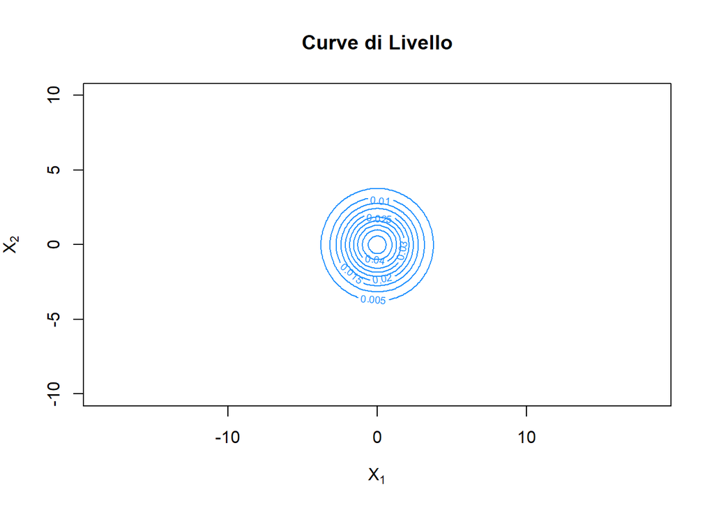

```r
z1 <- z2 <- seq(-10, 10, by = 0.1)
griglia <- expand.grid(z1, z2)
dens <- matrix(dmvnorm(griglia,
mean = medie,
sigma = varcov),
ncol = length(z1))
contour(z1, z2, dens,
asp = 1,
# nlevels = 3,
# levels = c(0.01, 0.02, 0.04, 0.07),
main = "Curve di Livello", xlab = expression(X[1]), ylab = expression(X[2]),
col = "dodgerblue")
```

By default the contour function automatically establishes the level curves to represent; And However, it is possible to specify the number of curves you want to obtain or even the specific values of the odds. As already observed in the scatterplot, we notice that the level curves have shape perfectly circular (equal axis length and consequently no specific orientation). The center of each circle is located at the point (0,0), corresponding to of the averages of the two components.

## Exercise 32

Consider the following distribution $(𝑋_1$, X_2) ∼ 𝑁 (_1, _2, _1^2, *2^2,* {12}) Bivariate Normal $𝑁 (2, 2, 100, 100, 4)$ and repeat the points from the previous exercise. In the representation of the contour lines, pay attention to the definition of the grid for the density calculation.

```r
require(mvtnorm)
medie <- c(2, 2)
varcov <- matrix(c(100, 4, 4, 100), ncol = 2)
set.seed(14263)
x <- rmvnorm(n = 3000, mean = medie, sigma = varcov)
```

Descriptive statistical analyzes (in this case the covariance is different from 0, therefore the two components cannot be considered independent).

```r
mean(x)
```

```
## [1] 1.666789
```

```r
cov(x)
```

```
##           [,1]       [,2]
## [1,] 99.482805   3.888923
## [2,]  3.888923 102.285964
```

Graph of empirical distribution functions

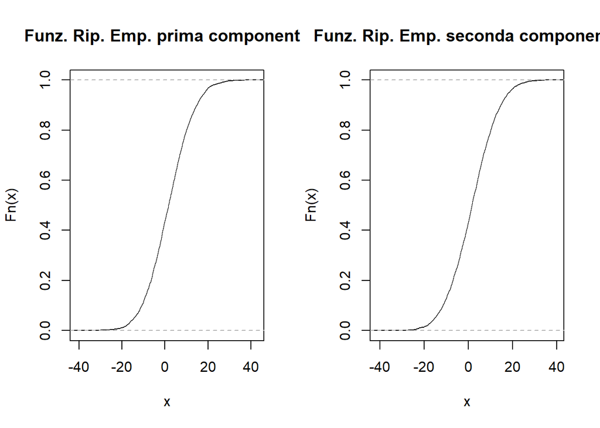

```r
par(mfrow = c(1, 2))
plot(ecdf(x[, 1]),
do.points = FALSE,
main = 'Funz. Rip. Emp. prima componente')
plot(ecdf(x[, 2]),
do.points = FALSE,
main = 'Funz. Rip. Emp. seconda componente')
```

.3

Scatter plot of the two components.

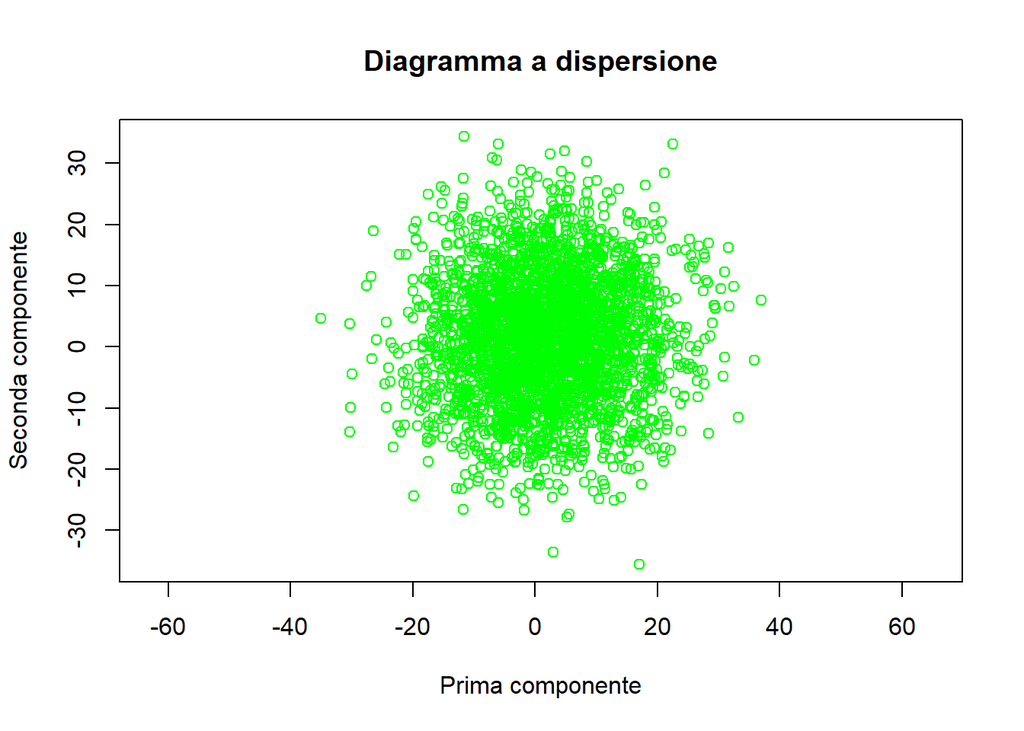

```r
plot(x[, 1], x[, 2],
col = "green",
asp = 1,
main = "Diagramma a dispersione",
xlab = "Prima componente",
ylab = "Seconda componente")
```

Although it is impossible to detect it precisely from the graph, it is known that the point cloud is in in this case centered in (2, 2), corresponding to the averages of the two components. It is also difficult to detect the orientation of the point cloud, which we know is upwards (the major axis of the ellipse is arranged along a straight line with a positive angular coefficient). The cause is the value of the variances that is significantly higher than that of the covariance. In fact, it is observed that the range of variation of two components is much higher than what was noted in the previous exercise. Let’s reiterate finally that, although the shape of the point cloud appears to be a circumference, it is this case an ellipse, given the value of the covariance different from 0.

##.4

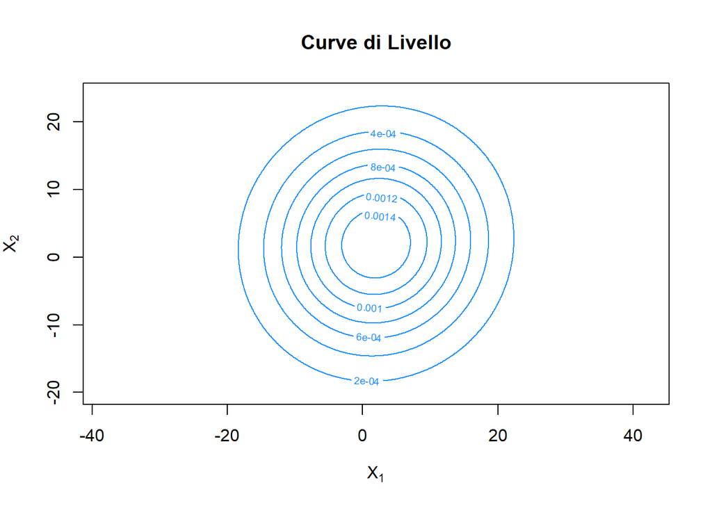

```r
z1 <- z2 <- seq(-20, 24, by = 0.1)
griglia <- expand.grid(z1, z2)
dens <- matrix(dmvnorm(griglia,
mean = medie,
sigma = varcov),
ncol = length(z1))
contour(z1, z2, dens,
   asp = 1,
# nlevels = 3,
# levels = c(0.01, 0.02, 0.04, 0.07),
main = "Curve di Livello", xlab = expression(X[1]), ylab = expression(X[2]),
col = "dodgerblue")
```

The interpretation and comments relating to the graph mostly follow those of the previous year; we simply observe that the values of the height of the parallel planes are significantly lower compared to those shown in the previous year. This testifies to a three-dimensional shape of the very lowest distribution, flattened and extended in the plane.

# Soluzioni esercizi “Applicazione dell’algoritmo EM”

## SOLUZIONI ESERCIZIO 33

Consider the example shown in the handouts of the usage part of the applications of the EM algorithm to impute the missing values of the contingency table. Yes consider the following observations for the absolute frequencies: $𝑦_{11} = 16, 𝑦_{12} = 7, 𝑦_{13} = 7, 𝑦_{21} = 𝑁 𝐴, 𝑦_{22} = 64, 𝑦_{23} = 5.$

1. Describe the functions that allow you to estimate the model parameters generalized linear for frequencies using the EM algorithm.
2. Describe the iterative process through the parameter estimates graph obtained at each iteration. Report and comment on the parameter estimates and the missing value.
3. Change the input parameter of the function to stop the algorithm having less than 20 iterations. Justify the result compared to the new ones parameter estimates.

.1

Si considera una tabella di contingenza costituita da 2 righe e 3 colonne e contenente un valore mancante (NA). Si utilizza l’algoritmo di Expectation-Maximization (EM) per stimare il dato mancante sulla base di un modello lineare $𝑦_{𝑖𝑗} = \mu + \alpha_i + \beta_i + \epsilon_{ij}$, dove $\mu$ è l’intercetta, $\alpha_i$ è il parametro di riga, $\beta_j$ è il parametro di colonna e $\epsilon_ij \sim 𝑁 (0, \sigma_2)$ è un termine di errore.

L’algoritmo EM è costituito da due passi (si vedano le dispense di applicazioni per maggiori dettagli):

- step E (expectation): by assigning an initial value to the missing value, the values are calculated of the model parameters;
- M step (maximization): the model parameters are used to estimate and update the value of the missing data. The em1 function defined below implements the two steps described; returns as output the value of all the estimated quantities.

```r
em1 <- function(y21, y){
ystar <- y
ystar[2, 1] <- y21
# Expectation Step
mu.hat <- mean(ystar)
alpha.hat <- apply(ystar, MAR = 1, mean) - mean(ystar)
beta.hat <- apply(ystar, MAR = 2, mean) - mean(ystar)
# Maximization Step
y21 <- mu.hat + alpha.hat[2] + beta.hat[1]
return(c(mu = mu.hat,
alpha = alpha.hat,
beta = beta.hat,
y21 = y21))
}
y <- matrix(c(16, 7, 7, NA, 64, 5), nrow = 2, ncol = 3, byrow = TRUE); y
```

```
##      [,1] [,2] [,3]
## [1,]   16    7    7
## [2,]   NA   64    5
```

```r
em1(19.8, y)
```

```
##     mu alpha1 alpha2  beta1  beta2  beta3    y21
##   19.8   -9.8    9.8   -1.9   15.7  -13.8   27.7
```

By executing the function, setting the value of 19.8 (even) as the initial value for the missing data to the average of the present data), the values shown above are obtained. In particular the value of missing frequency is estimated to be 27.7, thus updating the initially assigned value of 19.8.

The EM algorithm involves iterating the procedure by iterating these two steps until convergence. Yes it then iterates the execution of the em1 function through a while loop until the estimate of parameters remains “stable”, i.e. until the difference between the value of the two parameters subsequent iterations of the algorithm is less than a certain threshold 𝜀 (10−8 in the example below).

```r
em.step <- function(y, epsilon = 1e-8) {
trace <- NULL
convergenza <- FALSE
trace <- t(em1(y21 = mean(y, na.rm = TRUE), y = y))
y21id <- grep("y21", colnames(trace))
i <- 0
while(!convergenza) {
i <- i + 1
trace <- rbind(trace, em1(y21 = trace[i, "y21"], y = y))
convergenza <- (dist(trace[i:(i+1), -y21id]) < epsilon)
}
return(trace)
}
set.seed(183)
est <- em.step(y)
```

The generated output is a matrix of 51 rows and 7 columns. Each column represents a different parameter estimated by the model. The last column in particular is the value obtained for the data missing. Each row instead contains the estimates obtained at one iteration of the algorithm. For reaching convergence the EM algorithm therefore requires 51 iterations. Particularly in the last line we find the values of the convergent parameters (therefore “definitive”). The value of the missing data estimated through the EM algorithm is therefore equal to 43.5 (it must be approximated, since it is a frequency).

.2

Since reading the output matrix is not easy, we can represent the values obtained through a graph (trace plot). The matplot function is used which allows you to represent each of the data series contained in the matrix (we exclude the estimated value for the missing frequency).

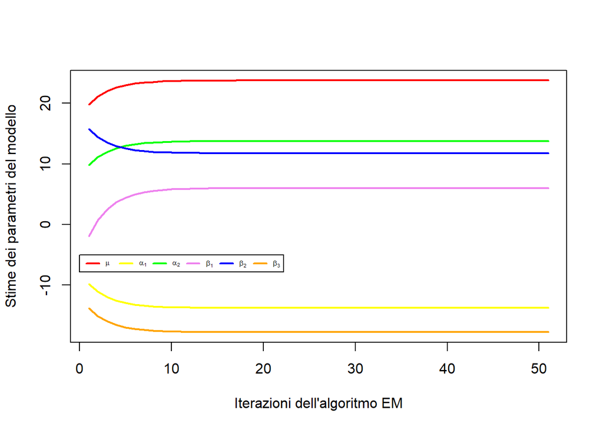

```r
names1 <- expression(mu, alpha[1], alpha[2], beta[1], beta[2], beta[3])
pal1 <- c("red", "yellow", "green", "violet", "blue", "orange")
matplot(est[, -7],
type = "l",
col = pal1,
lwd = 2,
lty = 1,
xlab = "Iterazioni dell'algoritmo EM",
ylab = "Stime dei parametri del modello")
legend(x = 0,
y = -5,
legend = names1,
lwd = 2 ,
col = pal1,
lty = 1,
horiz = TRUE,
cex = 0.5)
```

.3

Below we modify the em.step function in such a way that the stopping criterion of the EM algorithm does not both the convergence of the estimated parameters, but the achievement of a maximum number of iterations (NB. In practice the two conditions are often combined: convergence is required achieved, but if after a maximum number of iterations, the EM algorithm is still “running”, then it is blocked anyway. This maximum number of iterations is usually quite high. It is absolutely not recommended to use only having achieved the algorithm as a stop condition a maximum number of iterations.). No changes to the em1 function are needed. In function em.step only changes the definition of the convergence object (renamed maxit_reached).

```r
em.step <- function(y, maxit = 20) {
trace <- NULL
maxit_reached <- FALSE
trace <- t(em1(y21 = mean(y, na.rm = TRUE), y = y))
y21id <- grep("y21", colnames(trace))
i <- 0
while(!maxit_reached) {
i <- i + 1
trace <- rbind(trace, em1(y21 = trace[i, "y21"], y = y))
maxit_reached <- (i >= (maxit-1))
}
return(trace)
}
est_mod <- em.step(y, maxit = 20)
```

## Solutions to the “Mixture density” exercises

## Esercizio 36

1. Si utilizzi la funzione ’funcmxn‘ implementata a lezione per rappresentare graficamente i valori della densità della funzione miscuglio considerando il seguente scenario: $𝑋_1 \sim 𝑁 (1, 1.3), 𝑋_2 \sim𝑁 (0, 1.3)$ e peso per la prima componente $𝑝 = 0.32$.
2. Si crei la funzione chiamata ’rnormxn‘ che genera 1000 realizzazioni da entrambe le componeti definite al punto precedente e restituisce le corrispondenti realizzazioni del miscuglio di cui sopra.
3. Si riporti l’istogramma delle realizzazioni ottenute al punto .2 e si commenti il risultato.

## SOLUTIONS TO EXERCISE 36

.1

Let’s consider the funcmxn function implemented in class to graph the function of density of a mixture with two Gaussian components.

```r
funcmxn <- function(x, p, mu, sd){
f1 <- dnorm(x, mu[1], sd[1])
f2 <- dnorm(x, mu[2], sd[2])
f <- p*f1 + (1-p)*f2
f
}
```

We define the vectors for the means and standard deviations and the weight value of the first component; the function funcmxn determines the value of the density at the point (x) that is passed to it as input.

```r
mu <- c(1, 0)
sd <- c(sqrt(1.3), sqrt(1.3))
p <- 0.32
funcmxn(0.5, p, mu, sd)
```

```
## [1] 0.3178186
```

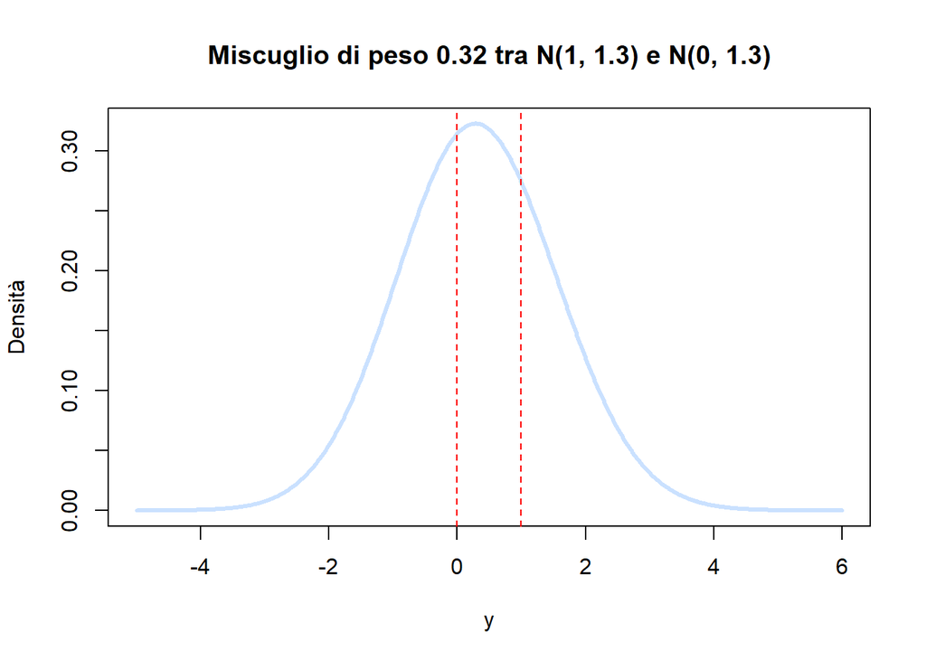

```r
y <- seq(-5, 6, by = 0.01)
pr <- funcmxn(x = y, p = p, mu = mu, sd = sd)
plot(y, pr,
xlab = "y", ylab = "Densità",
lwd = 3,
col = "lightsteelblue1",
type = "l",
main = "Miscuglio di peso 0.32 tra N(1, 1.3) e N(0, 1.3)")
abline(v = c(0, 1), lty = c(2, 2), col = c("red", "red"))
```

In this case the density graph does not allow the two components to be distinguished; is observed in fact a single maximum, with a central peak apparently symmetrical with respect to a point between 0 and 1 (the averages of the two components). The average values of the two components in fact they are too close to each other (in relation to a variance greater than 1), to be consistent to distinguish the two peaks. It would be necessary to increase the distance between the two averages or decrease it the value of the variance.

We define the function rnormxn which generates pseudo realizations from a mixture function with two Gaussian components. Similarly to the previous function, it requires the values of the as input weight of the first component (w) and the vectors of the means and variances of the two components. Everything is fine observation is extracted with probability equal to w from the first component and with equal probability 1-w from the second component.

```r
rnormxn <- function(n, w, mu, sd){
x = numeric(n)
for(i in 1:n){
dm = runif(1, 0, 1)
if(dm < w)
x[i] = rnorm(1, mu[1], sd[1])
else
x[i] = rnorm(1, mu[2], sd[2])
}
x
}

val <- rnormxn(1000, w = p, mu = mu, sd = sd)
summary(val)
```

```
##    Min. 1st Qu.  Median    Mean 3rd Qu.    Max.
## -3.6071 -0.4704  0.2855  0.3358  1.1425  4.1535
```

```r
var(val)
```

```
## [1] 1.441945
```

.3

The histogram of the realizations obtained in the previous point substantially confirms the observation of the previous point: the range of variation is rather limited, the (single) center of the distribution is slightly above 0, and the shape of the histogram is approximately symmetrical. The presence of a double maximum corresponding to the two components of the mixture is not noted.

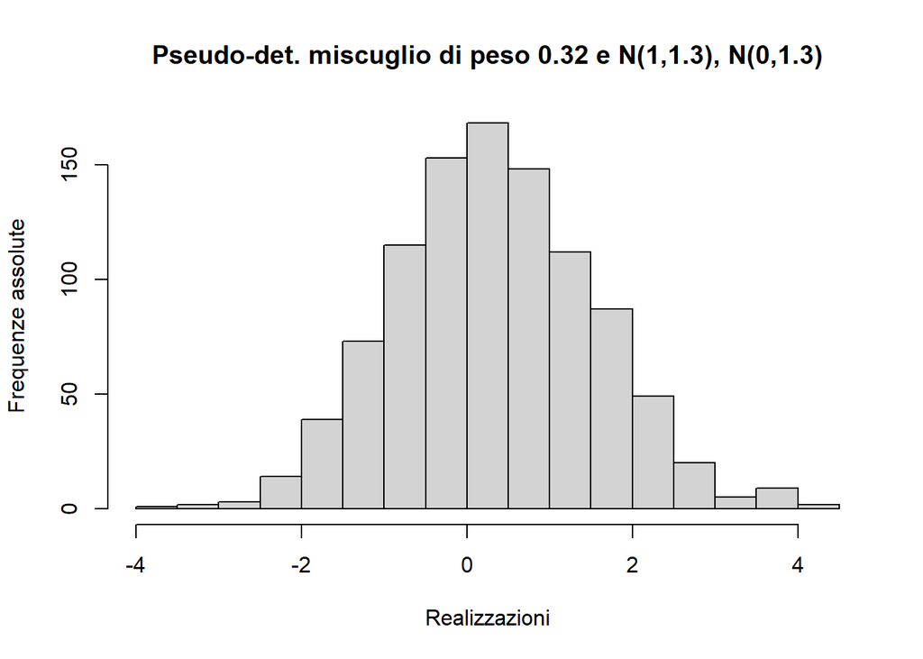

```r
hist(val,
breaks = 25,
ylab = "Frequenze assolute",
xlab = "Realizzazioni",
main = "Pseudo-det. miscuglio di peso 0.32 e N(1,1.3), N(0,1.3)")
```